# Heart Failure Prediction Project on 1025 dataset

**Context:** This data set dates from 1988 and consists of four databases: Cleveland, Hungary, Switzerland, and Long Beach V. It contains 76 attributes, including the predicted attribute, but all published experiments refer to using a subset of 14 of them. The "target" field refers to the presence of heart disease in the patient. It is integer valued 0 = no disease and 1 = disease. Content Attribute Information:

1. age
2. sex
3. chest pain type (4 values)
4. resting blood pressure
5. serum cholestoral in mg/dl
6. fasting blood sugar > 120 mg/dl
7. resting electrocardiographic results (values 0,1,2)
8. maximum heart rate achieved
9. exercise induced angina
10. oldpeak = ST depression induced by exercise relative to rest
11. the slope of the peak exercise ST segment
12. number of major vessels (0-3) colored by flourosopy
13. thal: 0 = normal; 1 = fixed defect; 2 = reversable defect The names and social security numbers of the patients were recently removed from the database, replaced with dummy values.

https://www.kaggle.com/datasets/johnsmith88/heart-disease-dataset

```python
import warnings
# Ignore all warnings
warnings.filterwarnings('ignore')
```

```python
!pip install pandas
```

```python
import pandas as pd
data = pd.read_csv('hf_1025.csv')
```

```python
data.head()
```

|  | age | sex | cp | trestbps | chol | fbs | restecg | thalach | exang | oldpeak | slope | ca | thal | target |
| --- | --- | --- | --- | --- | --- | --- | --- | --- | --- | --- | --- | --- | --- | --- |
| 0 | 52 | 1 | 0 | 125 | 212 | 0 | 1 | 168 | 0 | 1.0 | 2 | 2 | 3 | 0 |
| 1 | 53 | 1 | 0 | 140 | 203 | 1 | 0 | 155 | 1 | 3.1 | 0 | 0 | 3 | 0 |
| 2 | 70 | 1 | 0 | 145 | 174 | 0 | 1 | 125 | 1 | 2.6 | 0 | 0 | 3 | 0 |
| 3 | 61 | 1 | 0 | 148 | 203 | 0 | 1 | 161 | 0 | 0.0 | 2 | 1 | 3 | 0 |
| 4 | 62 | 0 | 0 | 138 | 294 | 1 | 1 | 106 | 0 | 1.9 | 1 | 3 | 2 | 0 |

```python
data.shape
```

```
(1025, 14)
```

```python
data.columns
```

```
Index(['age', 'sex', 'cp', 'trestbps', 'chol', 'fbs', 'restecg', 'thalach',
       'exang', 'oldpeak', 'slope', 'ca', 'thal', 'target'],
      dtype='object')
```

```python
data.isnull().sum()
```

```
age         0
sex         0
cp          0
trestbps    0
chol        0
fbs         0
restecg     0
thalach     0
exang       0
oldpeak     0
slope       0
ca          0
thal        0
target      0
dtype: int64
```

```python
!pip install --upgrade scikit-learn
!pip install --upgrade imbalanced-learn
```

## Prepare and load the dataset

```python
import pandas as pd
from imblearn.over_sampling import SMOTE
from sklearn.model_selection import train_test_split
from sklearn.preprocessing import StandardScaler

# Load dataset
data = pd.read_csv('hf_1025.csv')

# fill missing values with mean values
data.fillna(data.mean(), inplace=True)

# Define features and target
X = data[['age', 'sex', 'cp', 'trestbps', 'chol', 'fbs', 'restecg', 'thalach',
       'exang', 'oldpeak', 'slope', 'ca', 'thal']]
y = data['target']

# Apply SMOTE to balance the dataset
smote = SMOTE(random_state=42)
X_resampled, y_resampled = smote.fit_resample(X, y)

# Split data
X_train, X_test, y_train, y_test = train_test_split(X_resampled, y_resampled, test_size=0.2, random_state=42)

# Scale features
scaler = StandardScaler()
X_train = scaler.fit_transform(X_train)
X_test = scaler.transform(X_test)
```

```
Logistic Regression on dataset
              precision    recall  f1-score   support

           0       0.84      0.76      0.79        94
           1       0.82      0.88      0.85       117

    accuracy                           0.82       211
   macro avg       0.83      0.82      0.82       211
weighted avg       0.83      0.82      0.82       211

ROC AUC: 0.91
```

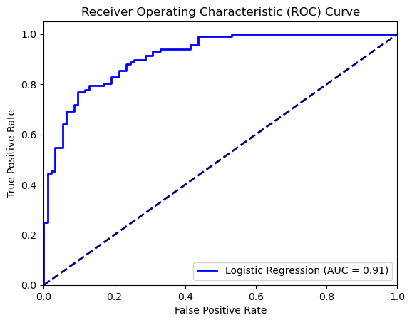

```python
from sklearn.linear_model import LogisticRegression
from sklearn.metrics import classification_report, roc_auc_score, roc_curve
import matplotlib.pyplot as plt

# Logistic Regression with L2 regularization
lr = LogisticRegression(C=1.0, penalty='l2', solver='liblinear', random_state=42)
lr.fit(X_train, y_train)

# Predictions
y_pred_lr = lr.predict(X_test)
y_proba_lr = lr.predict_proba(X_test)[:, 1]

# Evaluation
print("Logistic Regression on dataset")
print(classification_report(y_test, y_pred_lr))
roc_auc_lr = roc_auc_score(y_test, y_proba_lr)
print(f'ROC AUC: {roc_auc_lr:.2f}')

# Plot the ROC curve
fpr_lr, tpr_lr, _ = roc_curve(y_test, y_proba_lr)
plt.figure()
plt.plot(fpr_lr, tpr_lr, color='blue', lw=2, label=f'Logistic Regression (AUC = {roc_auc_lr:.2f})')
plt.plot([0, 1], [0, 1], color='navy', lw=2, linestyle='--')
plt.xlim([0.0, 1.0])
plt.ylim([0.0, 1.05])
plt.xlabel('False Positive Rate')
plt.ylabel('True Positive Rate')
plt.title('Receiver Operating Characteristic (ROC) Curve')
plt.legend(loc="lower right")
plt.show()
```

```
Support Vector Machine on dataset
              precision    recall  f1-score   support

           0       0.82      0.73      0.78        94
           1       0.80      0.87      0.84       117

    accuracy                           0.81       211
   macro avg       0.81      0.80      0.81       211
weighted avg       0.81      0.81      0.81       211

ROC AUC: 0.91
```

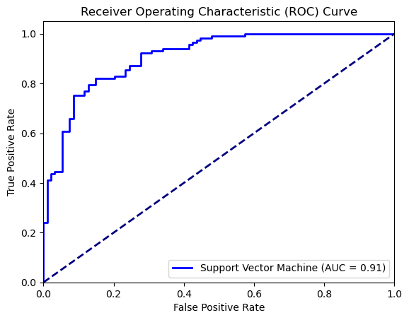

```python
from sklearn.svm import SVC

# Support Vector Machine with reduced complexity
svm = SVC(C=1.0, kernel='linear', probability=True, random_state=42)
svm.fit(X_train, y_train)

# Predictions
y_pred_svm = svm.predict(X_test)
y_proba_svm = svm.predict_proba(X_test)[:, 1]

# Evaluation
print("Support Vector Machine on dataset")
print(classification_report(y_test, y_pred_svm))
roc_auc_svm = roc_auc_score(y_test, y_proba_svm)
print(f'ROC AUC: {roc_auc_svm:.2f}')

# Plot the ROC curve
fpr_svm, tpr_svm, _ = roc_curve(y_test, y_proba_svm)
plt.figure()
plt.plot(fpr_svm, tpr_svm, color='blue', lw=2, label=f'Support Vector Machine (AUC = {roc_auc_svm:.2f})')
plt.plot([0, 1], [0, 1], color='navy', lw=2, linestyle='--')
plt.xlim([0.0, 1.0])
plt.ylim([0.0, 1.05])
plt.xlabel('False Positive Rate')
plt.ylabel('True Positive Rate')
plt.title('Receiver Operating Characteristic (ROC) Curve')
plt.legend(loc="lower right")
plt.show()
```

```python
from sklearn.ensemble import RandomForestClassifier

# Random Forest: base model with further reduced complexity
rf = RandomForestClassifier(max_depth=3, n_estimators=30, min_samples_leaf=5, random_state=42)
rf.fit(X_train, y_train)

# Predictions
y_pred_rf = rf.predict(X_test)
y_proba_rf = rf.predict_proba(X_test)[:, 1]

# Evaluation
print("Random Forest")
print(classification_report(y_test, y_pred_rf))
roc_auc_rf = roc_auc_score(y_test, y_proba_rf)
print(f'ROC AUC: {roc_auc_rf:.2f}')
```

```
Random Forest
              precision    recall  f1-score   support

           0       0.92      0.88      0.90        94
           1       0.91      0.94      0.92       117

    accuracy                           0.91       211
   macro avg       0.92      0.91      0.91       211
weighted avg       0.91      0.91      0.91       211

ROC AUC: 0.95
```

```python
from sklearn.ensemble import GradientBoostingClassifier

# Gradient Boosting Machine
gbm = GradientBoostingClassifier(max_depth=3, n_estimators=30, min_samples_leaf=5, random_state=42)
gbm.fit(X_train, y_train)

# Predictions
y_pred_gbm = gbm.predict(X_test)
y_proba_gbm = gbm.predict_proba(X_test)[:, 1]

# Evaluation
print("Gradient Boosting Machine")
print(classification_report(y_test, y_pred_gbm))
roc_auc_gbm = roc_auc_score(y_test, y_proba_gbm)
print(f'ROC AUC: {roc_auc_gbm:.2f}')
```

```
Gradient Boosting Machine
              precision    recall  f1-score   support

           0       0.93      0.87      0.90        94
           1       0.90      0.95      0.93       117

    accuracy                           0.91       211
   macro avg       0.92      0.91      0.91       211
weighted avg       0.92      0.91      0.91       211

ROC AUC: 0.97
```

```python
!pip install xgboost
```

```python
from xgboost import XGBClassifier
from sklearn.metrics import classification_report, roc_auc_score

# XGBoost Classifier
xgbm = XGBClassifier(max_depth=3, min_child_weight=10, subsample=0.7, colsample_bytree=0.7, random_state=42)
xgbm.fit(X_train, y_train)

# Predictions
y_pred_xgbm = xgbm.predict(X_test)
y_proba_xgbm = xgbm.predict_proba(X_test)[:, 1]

# Evaluation
print("XGBoost Classifier")
print(classification_report(y_test, y_pred_xgbm))
roc_auc_xgbm = roc_auc_score(y_test, y_proba_xgbm)
print(f'ROC AUC: {roc_auc_xgbm:.2f}')
```

```
XGBoost Classifier
              precision    recall  f1-score   support

           0       0.91      0.93      0.92        94
           1       0.94      0.92      0.93       117

    accuracy                           0.92       211
   macro avg       0.92      0.92      0.92       211
weighted avg       0.92      0.92      0.92       211

ROC AUC: 0.98
```

```python
!pip install tensorflow
```

```
21/21 ━━━━━━━━━━━━━━━━━━━━ 0s 3ms/step - accuracy: 0.3959 - loss: 0.9150 - val_accuracy: 0.4675 - val_loss: 0.7036
21/21 ━━━━━━━━━━━━━━━━━━━━ 0s 1ms/step - accuracy: 0.5175 - loss: 0.7459 - val_accuracy: 0.6154 - val_loss: 0.6519
21/21 ━━━━━━━━━━━━━━━━━━━━ 0s 1ms/step - accuracy: 0.5426 - loss: 0.7423 - val_accuracy: 0.7160 - val_loss: 0.6159
21/21 ━━━━━━━━━━━━━━━━━━━━ 0s 1ms/step - accuracy: 0.5852 - loss: 0.6748 - val_accuracy: 0.7811 - val_loss: 0.5858
21/21 ━━━━━━━━━━━━━━━━━━━━ 0s 952us/step - accuracy: 0.6876 - loss: 0.6225 - val_accuracy: 0.8107 - val_loss: 0.5563
21/21 ━━━━━━━━━━━━━━━━━━━━ 0s 990us/step - accuracy: 0.6486 - loss: 0.6136 - val_accuracy: 0.8166 - val_loss: 0.5252
21/21 ━━━━━━━━━━━━━━━━━━━━ 0s 939us/step - accuracy: 0.7140 - loss: 0.5633 - val_accuracy: 0.8107 - val_loss: 0.4990
21/21 ━━━━━━━━━━━━━━━━━━━━ 0s 1ms/step - accuracy: 0.7194 - loss: 0.5374 - val_accuracy: 0.8166 - val_loss: 0.4747
21/21 ━━━━━━━━━━━━━━━━━━━━ 0s 953us/step - accuracy: 0.7740 - loss: 0.4814 - val_accuracy: 0.8047 - val_loss: 0.4519
21/21 ━━━━━━━━━━━━━━━━━━━━ 0s 984us/step - accuracy: 0.7641 - loss: 0.4877 - val_accuracy: 0.8166 - val_loss: 0.4378
21/21 ━━━━━━━━━━━━━━━━━━━━ 0s 922us/step - accuracy: 0.7719 - loss: 0.4600 - val_accuracy: 0.8107 - val_loss: 0.4264
21/21 ━━━━━━━━━━━━━━━━━━━━ 0s 962us/step - accuracy: 0.7543 - loss: 0.5066 - val_accuracy: 0.8107 - val_loss: 0.4183
21/21 ━━━━━━━━━━━━━━━━━━━━ 0s 970us/step - accuracy: 0.7768 - loss: 0.4972 - val_accuracy: 0.8107 - val_loss: 0.4114
21/21 ━━━━━━━━━━━━━━━━━━━━ 0s 914us/step - accuracy: 0.7811 - loss: 0.4461 - val_accuracy: 0.8047 - val_loss: 0.4031
21/21 ━━━━━━━━━━━━━━━━━━━━ 0s 1ms/step - accuracy: 0.7830 - loss: 0.4697 - val_accuracy: 0.8225 - val_loss: 0.3969
21/21 ━━━━━━━━━━━━━━━━━━━━ 0s 981us/step - accuracy: 0.7793 - loss: 0.4727 - val_accuracy: 0.8166 - val_loss: 0.3943
21/21 ━━━━━━━━━━━━━━━━━━━━ 0s 965us/step - accuracy: 0.7877 - loss: 0.4796 - val_accuracy: 0.8166 - val_loss: 0.3906
21/21 ━━━━━━━━━━━━━━━━━━━━ 0s 974us/step - accuracy: 0.8014 - loss: 0.4476 - val_accuracy: 0.8166 - val_loss: 0.3886
21/21 ━━━━━━━━━━━━━━━━━━━━ 0s 930us/step - accuracy: 0.7997 - loss: 0.4089 - val_accuracy: 0.8166 - val_loss: 0.3852
21/21 ━━━━━━━━━━━━━━━━━━━━ 0s 936us/step - accuracy: 0.8144 - loss: 0.4110 - val_accuracy: 0.8166 - val_loss: 0.3811
21/21 ━━━━━━━━━━━━━━━━━━━━ 0s 933us/step - accuracy: 0.8194 - loss: 0.4372 - val_accuracy: 0.8166 - val_loss: 0.3797
21/21 ━━━━━━━━━━━━━━━━━━━━ 0s 944us/step - accuracy: 0.8473 - loss: 0.3762 - val_accuracy: 0.8107 - val_loss: 0.3751
21/21 ━━━━━━━━━━━━━━━━━━━━ 0s 998us/step - accuracy: 0.8438 - loss: 0.3751 - val_accuracy: 0.8107 - val_loss: 0.3727
21/21 ━━━━━━━━━━━━━━━━━━━━ 0s 903us/step - accuracy: 0.7956 - loss: 0.4066 - val_accuracy: 0.8107 - val_loss: 0.3709
21/21 ━━━━━━━━━━━━━━━━━━━━ 0s 972us/step - accuracy: 0.8284 - loss: 0.4071 - val_accuracy: 0.8107 - val_loss: 0.3683
21/21 ━━━━━━━━━━━━━━━━━━━━ 0s 931us/step - accuracy: 0.8492 - loss: 0.3311 - val_accuracy: 0.8107 - val_loss: 0.3683
21/21 ━━━━━━━━━━━━━━━━━━━━ 0s 932us/step - accuracy: 0.8236 - loss: 0.4136 - val_accuracy: 0.8107 - val_loss: 0.3677
21/21 ━━━━━━━━━━━━━━━━━━━━ 0s 987us/step - accuracy: 0.8294 - loss: 0.3803 - val_accuracy: 0.8225 - val_loss: 0.3670
21/21 ━━━━━━━━━━━━━━━━━━━━ 0s 907us/step - accuracy: 0.7935 - loss: 0.4229 - val_accuracy: 0.8225 - val_loss: 0.3654
21/21 ━━━━━━━━━━━━━━━━━━━━ 0s 977us/step - accuracy: 0.8527 - loss: 0.3633 - val_accuracy: 0.8225 - val_loss: 0.3645
21/21 ━━━━━━━━━━━━━━━━━━━━ 0s 952us/step - accuracy: 0.8385 - loss: 0.4061 - val_accuracy: 0.8225 - val_loss: 0.3621
21/21 ━━━━━━━━━━━━━━━━━━━━ 0s 911us/step - accuracy: 0.8479 - loss: 0.3578 - val_accuracy: 0.8225 - val_loss: 0.3623
21/21 ━━━━━━━━━━━━━━━━━━━━ 0s 979us/step - accuracy: 0.8590 - loss: 0.3745 - val_accuracy: 0.8225 - val_loss: 0.3604
21/21 ━━━━━━━━━━━━━━━━━━━━ 0s 934us/step - accuracy: 0.8318 - loss: 0.3963 - val_accuracy: 0.8402 - val_loss: 0.3589
21/21 ━━━━━━━━━━━━━━━━━━━━ 0s 931us/step - accuracy: 0.8489 - loss: 0.3831 - val_accuracy: 0.8402 - val_loss: 0.3587
21/21 ━━━━━━━━━━━━━━━━━━━━ 0s 1ms/step - accuracy: 0.8622 - loss: 0.3831 - val_accuracy: 0.8402 - val_loss: 0.3593
21/21 ━━━━━━━━━━━━━━━━━━━━ 0s 912us/step - accuracy: 0.8508 - loss: 0.3734 - val_accuracy: 0.8402 - val_loss: 0.3569
21/21 ━━━━━━━━━━━━━━━━━━━━ 0s 1ms/step - accuracy: 0.8853 - loss: 0.3188 - val_accuracy: 0.8225 - val_loss: 0.3586
21/21 ━━━━━━━━━━━━━━━━━━━━ 0s 945us/step - accuracy: 0.8698 - loss: 0.3595 - val_accuracy: 0.8462 - val_loss: 0.3564
21/21 ━━━━━━━━━━━━━━━━━━━━ 0s 4ms/step - accuracy: 0.8507 - loss: 0.3827 - val_accuracy: 0.8462 - val_loss: 0.3551
21/21 ━━━━━━━━━━━━━━━━━━━━ 0s 1ms/step - accuracy: 0.8479 - loss: 0.3480 - val_accuracy: 0.8462 - val_loss: 0.3538
```

[output cut: 21 more lines]

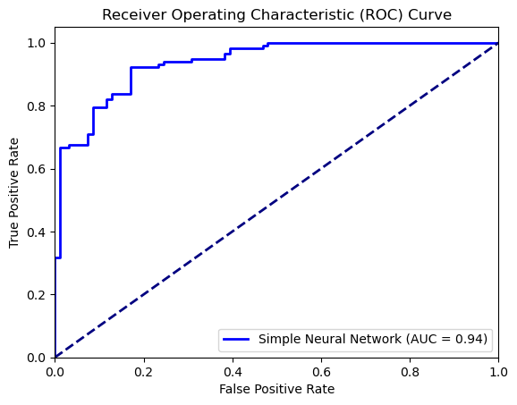

```python
import tensorflow as tf
from tensorflow.keras.models import Sequential
from tensorflow.keras.layers import Dense, Dropout

# Define input_dim based on your dataset
input_dim = X_train.shape[1]

# Simple Neural Network with reduced complexity
model_nn = Sequential([
    Dense(32, activation='relu', input_shape=(input_dim,)),
    Dropout(0.5),
    Dense(16, activation='relu'),
    Dropout(0.5),
    Dense(1, activation='sigmoid')
])

model_nn.compile(optimizer='adam', loss='binary_crossentropy', metrics=['accuracy'])

# Train the model
model_nn.fit(X_train, y_train, epochs=50, batch_size=32, validation_split=0.2)

# Predictions
y_pred_nn = model_nn.predict(X_test).ravel()
y_pred_nn_class = (y_pred_nn > 0.5).astype(int)

# Evaluation
print("Simple Neural Network on dataset")
print(classification_report(y_test, y_pred_nn_class))
roc_auc_nn = roc_auc_score(y_test, y_pred_nn)
print(f'ROC AUC: {roc_auc_nn:.2f}')

# Plot the ROC curve
fpr_nn, tpr_nn, _ = roc_curve(y_test, y_pred_nn)
plt.figure()
plt.plot(fpr_nn, tpr_nn, color='blue', lw=2, label=f'Simple Neural Network (AUC = {roc_auc_nn:.2f})')
plt.plot([0, 1], [0, 1], color='navy', lw=2, linestyle='--')
plt.xlim([0.0, 1.0])
plt.ylim([0.0, 1.05])
plt.xlabel('False Positive Rate')
plt.ylabel('True Positive Rate')
plt.title('Receiver Operating Characteristic (ROC) Curve')
plt.legend(loc="lower right")
plt.show()
```

```python
# Reshape data to add timesteps dimension (e.g., timesteps=1)
X_train_reshaped = X_train.reshape((X_train.shape[0], X_train.shape[1], 1))
X_test_reshaped = X_test.reshape((X_test.shape[0], X_test.shape[1], 1))

# Update input_dim and timesteps
timesteps = X_train_reshaped.shape[1]
input_dim = X_train_reshaped.shape[2]
```

```
21/21 ━━━━━━━━━━━━━━━━━━━━ 0s 4ms/step - accuracy: 0.5488 - loss: 0.6984 - val_accuracy: 0.7160 - val_loss: 0.6151
21/21 ━━━━━━━━━━━━━━━━━━━━ 0s 1ms/step - accuracy: 0.6602 - loss: 0.6234 - val_accuracy: 0.7160 - val_loss: 0.5713
21/21 ━━━━━━━━━━━━━━━━━━━━ 0s 1ms/step - accuracy: 0.7051 - loss: 0.5840 - val_accuracy: 0.7337 - val_loss: 0.5342
21/21 ━━━━━━━━━━━━━━━━━━━━ 0s 1ms/step - accuracy: 0.7466 - loss: 0.5463 - val_accuracy: 0.7337 - val_loss: 0.5097
21/21 ━━━━━━━━━━━━━━━━━━━━ 0s 1ms/step - accuracy: 0.7529 - loss: 0.5359 - val_accuracy: 0.7515 - val_loss: 0.4966
21/21 ━━━━━━━━━━━━━━━━━━━━ 0s 1ms/step - accuracy: 0.7478 - loss: 0.5124 - val_accuracy: 0.7633 - val_loss: 0.4874
21/21 ━━━━━━━━━━━━━━━━━━━━ 0s 1ms/step - accuracy: 0.7794 - loss: 0.5115 - val_accuracy: 0.7692 - val_loss: 0.4845
21/21 ━━━━━━━━━━━━━━━━━━━━ 0s 1ms/step - accuracy: 0.7753 - loss: 0.4849 - val_accuracy: 0.7811 - val_loss: 0.4814
21/21 ━━━━━━━━━━━━━━━━━━━━ 0s 1ms/step - accuracy: 0.7628 - loss: 0.4985 - val_accuracy: 0.7692 - val_loss: 0.4773
21/21 ━━━━━━━━━━━━━━━━━━━━ 0s 1ms/step - accuracy: 0.7612 - loss: 0.4646 - val_accuracy: 0.7692 - val_loss: 0.4758
21/21 ━━━━━━━━━━━━━━━━━━━━ 0s 1ms/step - accuracy: 0.7612 - loss: 0.4975 - val_accuracy: 0.7633 - val_loss: 0.4734
21/21 ━━━━━━━━━━━━━━━━━━━━ 0s 1ms/step - accuracy: 0.7775 - loss: 0.4751 - val_accuracy: 0.7633 - val_loss: 0.4720
21/21 ━━━━━━━━━━━━━━━━━━━━ 0s 1ms/step - accuracy: 0.8017 - loss: 0.4246 - val_accuracy: 0.7692 - val_loss: 0.4695
21/21 ━━━━━━━━━━━━━━━━━━━━ 0s 1ms/step - accuracy: 0.7850 - loss: 0.4782 - val_accuracy: 0.7633 - val_loss: 0.4674
21/21 ━━━━━━━━━━━━━━━━━━━━ 0s 1ms/step - accuracy: 0.7968 - loss: 0.4437 - val_accuracy: 0.7751 - val_loss: 0.4627
21/21 ━━━━━━━━━━━━━━━━━━━━ 0s 1ms/step - accuracy: 0.7789 - loss: 0.4591 - val_accuracy: 0.7751 - val_loss: 0.4612
21/21 ━━━━━━━━━━━━━━━━━━━━ 0s 1ms/step - accuracy: 0.8009 - loss: 0.4459 - val_accuracy: 0.7692 - val_loss: 0.4588
21/21 ━━━━━━━━━━━━━━━━━━━━ 0s 1ms/step - accuracy: 0.7772 - loss: 0.5052 - val_accuracy: 0.7633 - val_loss: 0.4580
21/21 ━━━━━━━━━━━━━━━━━━━━ 0s 1ms/step - accuracy: 0.8054 - loss: 0.4544 - val_accuracy: 0.7751 - val_loss: 0.4566
21/21 ━━━━━━━━━━━━━━━━━━━━ 0s 1ms/step - accuracy: 0.7946 - loss: 0.4467 - val_accuracy: 0.7633 - val_loss: 0.4544
21/21 ━━━━━━━━━━━━━━━━━━━━ 0s 1ms/step - accuracy: 0.8311 - loss: 0.4252 - val_accuracy: 0.7574 - val_loss: 0.4517
21/21 ━━━━━━━━━━━━━━━━━━━━ 0s 1ms/step - accuracy: 0.7674 - loss: 0.4589 - val_accuracy: 0.7633 - val_loss: 0.4482
21/21 ━━━━━━━━━━━━━━━━━━━━ 0s 1ms/step - accuracy: 0.7778 - loss: 0.4613 - val_accuracy: 0.7692 - val_loss: 0.4477
21/21 ━━━━━━━━━━━━━━━━━━━━ 0s 1ms/step - accuracy: 0.7344 - loss: 0.4965 - val_accuracy: 0.7692 - val_loss: 0.4471
21/21 ━━━━━━━━━━━━━━━━━━━━ 0s 1ms/step - accuracy: 0.8036 - loss: 0.4276 - val_accuracy: 0.7574 - val_loss: 0.4480
21/21 ━━━━━━━━━━━━━━━━━━━━ 0s 1ms/step - accuracy: 0.7954 - loss: 0.4623 - val_accuracy: 0.7692 - val_loss: 0.4469
21/21 ━━━━━━━━━━━━━━━━━━━━ 0s 1ms/step - accuracy: 0.8002 - loss: 0.4325 - val_accuracy: 0.7692 - val_loss: 0.4457
21/21 ━━━━━━━━━━━━━━━━━━━━ 0s 1ms/step - accuracy: 0.8212 - loss: 0.4048 - val_accuracy: 0.7751 - val_loss: 0.4432
21/21 ━━━━━━━━━━━━━━━━━━━━ 0s 1ms/step - accuracy: 0.7913 - loss: 0.4307 - val_accuracy: 0.7692 - val_loss: 0.4422
21/21 ━━━━━━━━━━━━━━━━━━━━ 0s 1ms/step - accuracy: 0.8061 - loss: 0.4501 - val_accuracy: 0.7692 - val_loss: 0.4414
21/21 ━━━━━━━━━━━━━━━━━━━━ 0s 1ms/step - accuracy: 0.7922 - loss: 0.4177 - val_accuracy: 0.7692 - val_loss: 0.4368
21/21 ━━━━━━━━━━━━━━━━━━━━ 0s 1ms/step - accuracy: 0.7870 - loss: 0.4407 - val_accuracy: 0.7988 - val_loss: 0.4373
21/21 ━━━━━━━━━━━━━━━━━━━━ 0s 1ms/step - accuracy: 0.8174 - loss: 0.4265 - val_accuracy: 0.7811 - val_loss: 0.4357
21/21 ━━━━━━━━━━━━━━━━━━━━ 0s 1ms/step - accuracy: 0.8085 - loss: 0.3968 - val_accuracy: 0.7751 - val_loss: 0.4329
21/21 ━━━━━━━━━━━━━━━━━━━━ 0s 1ms/step - accuracy: 0.7880 - loss: 0.4668 - val_accuracy: 0.7633 - val_loss: 0.4329
21/21 ━━━━━━━━━━━━━━━━━━━━ 0s 1ms/step - accuracy: 0.7702 - loss: 0.4682 - val_accuracy: 0.7692 - val_loss: 0.4333
21/21 ━━━━━━━━━━━━━━━━━━━━ 0s 1ms/step - accuracy: 0.7873 - loss: 0.4315 - val_accuracy: 0.7692 - val_loss: 0.4324
21/21 ━━━━━━━━━━━━━━━━━━━━ 0s 1ms/step - accuracy: 0.8072 - loss: 0.4250 - val_accuracy: 0.7751 - val_loss: 0.4297
21/21 ━━━━━━━━━━━━━━━━━━━━ 0s 1ms/step - accuracy: 0.8302 - loss: 0.3943 - val_accuracy: 0.7751 - val_loss: 0.4282
21/21 ━━━━━━━━━━━━━━━━━━━━ 0s 1ms/step - accuracy: 0.8171 - loss: 0.4045 - val_accuracy: 0.7751 - val_loss: 0.4264
21/21 ━━━━━━━━━━━━━━━━━━━━ 0s 1ms/step - accuracy: 0.8418 - loss: 0.3632 - val_accuracy: 0.7751 - val_loss: 0.4242
```

[output cut: 21 more lines]

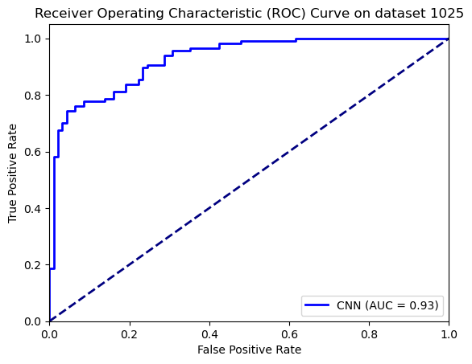

```python
from tensorflow.keras.layers import Conv1D, MaxPooling1D, Flatten

# Define input_dim and timesteps based on your dataset
timesteps = X_train_reshaped.shape[1]
input_dim = X_train_reshaped.shape[2]

# CNN Model
model_cnn = Sequential([
    Conv1D(32, kernel_size=3, activation='relu', input_shape=(timesteps, input_dim)),
    MaxPooling1D(pool_size=2),
    Dropout(0.5),
    Flatten(),
    Dense(32, activation='relu'),
    Dropout(0.5),
    Dense(1, activation='sigmoid')
])

model_cnn.compile(optimizer='adam', loss='binary_crossentropy', metrics=['accuracy'])

# Train the model
model_cnn.fit(X_train_reshaped, y_train, epochs=50, batch_size=32, validation_split=0.2)

# Predictions
y_pred_cnn = model_cnn.predict(X_test_reshaped).ravel()
y_pred_cnn_class = (y_pred_cnn > 0.5).astype(int)

# Evaluation
print("CNN on dataset 1025")
print(classification_report(y_test, y_pred_cnn_class))
roc_auc_cnn = roc_auc_score(y_test, y_pred_cnn)
print(f'ROC AUC: {roc_auc_cnn:.2f}')

# Plot the ROC curve
fpr_cnn, tpr_cnn, _ = roc_curve(y_test, y_pred_cnn)
plt.figure()
plt.plot(fpr_cnn, tpr_cnn, color='blue', lw=2, label=f'CNN (AUC = {roc_auc_cnn:.2f})')
plt.plot([0, 1], [0, 1], color='navy', lw=2, linestyle='--')
plt.xlim([0.0, 1.0])
plt.ylim([0.0, 1.05])
plt.xlabel('False Positive Rate')
plt.ylabel('True Positive Rate')
plt.title('Receiver Operating Characteristic (ROC) Curve on dataset 1025')
plt.legend(loc="lower right")
plt.show()
```

```
21/21 ━━━━━━━━━━━━━━━━━━━━ 1s 11ms/step - accuracy: 0.4724 - loss: 0.6982 - val_accuracy: 0.5917 - val_loss: 0.6867
21/21 ━━━━━━━━━━━━━━━━━━━━ 0s 4ms/step - accuracy: 0.6264 - loss: 0.6777 - val_accuracy: 0.5621 - val_loss: 0.6798
21/21 ━━━━━━━━━━━━━━━━━━━━ 0s 4ms/step - accuracy: 0.6110 - loss: 0.6585 - val_accuracy: 0.5444 - val_loss: 0.6785
21/21 ━━━━━━━━━━━━━━━━━━━━ 0s 4ms/step - accuracy: 0.6194 - loss: 0.6424 - val_accuracy: 0.5503 - val_loss: 0.6777
21/21 ━━━━━━━━━━━━━━━━━━━━ 0s 4ms/step - accuracy: 0.6127 - loss: 0.6448 - val_accuracy: 0.5503 - val_loss: 0.6770
21/21 ━━━━━━━━━━━━━━━━━━━━ 0s 4ms/step - accuracy: 0.6660 - loss: 0.6220 - val_accuracy: 0.5444 - val_loss: 0.6769
21/21 ━━━━━━━━━━━━━━━━━━━━ 0s 4ms/step - accuracy: 0.6434 - loss: 0.6348 - val_accuracy: 0.5858 - val_loss: 0.6664
21/21 ━━━━━━━━━━━━━━━━━━━━ 0s 4ms/step - accuracy: 0.7207 - loss: 0.5920 - val_accuracy: 0.6272 - val_loss: 0.6536
21/21 ━━━━━━━━━━━━━━━━━━━━ 0s 4ms/step - accuracy: 0.7312 - loss: 0.5609 - val_accuracy: 0.6509 - val_loss: 0.6311
21/21 ━━━━━━━━━━━━━━━━━━━━ 0s 4ms/step - accuracy: 0.7690 - loss: 0.5613 - val_accuracy: 0.6627 - val_loss: 0.6226
21/21 ━━━━━━━━━━━━━━━━━━━━ 0s 4ms/step - accuracy: 0.7473 - loss: 0.5239 - val_accuracy: 0.6746 - val_loss: 0.6193
21/21 ━━━━━━━━━━━━━━━━━━━━ 0s 4ms/step - accuracy: 0.7441 - loss: 0.5266 - val_accuracy: 0.6450 - val_loss: 0.6241
21/21 ━━━━━━━━━━━━━━━━━━━━ 0s 4ms/step - accuracy: 0.7439 - loss: 0.5629 - val_accuracy: 0.6864 - val_loss: 0.6193
21/21 ━━━━━━━━━━━━━━━━━━━━ 0s 4ms/step - accuracy: 0.7702 - loss: 0.5037 - val_accuracy: 0.6805 - val_loss: 0.6214
21/21 ━━━━━━━━━━━━━━━━━━━━ 0s 4ms/step - accuracy: 0.7794 - loss: 0.5242 - val_accuracy: 0.6923 - val_loss: 0.6209
21/21 ━━━━━━━━━━━━━━━━━━━━ 0s 4ms/step - accuracy: 0.7449 - loss: 0.5648 - val_accuracy: 0.6923 - val_loss: 0.6222
21/21 ━━━━━━━━━━━━━━━━━━━━ 0s 4ms/step - accuracy: 0.7717 - loss: 0.5156 - val_accuracy: 0.6982 - val_loss: 0.6265
21/21 ━━━━━━━━━━━━━━━━━━━━ 0s 4ms/step - accuracy: 0.7556 - loss: 0.5314 - val_accuracy: 0.6923 - val_loss: 0.6233
21/21 ━━━━━━━━━━━━━━━━━━━━ 0s 4ms/step - accuracy: 0.7857 - loss: 0.5048 - val_accuracy: 0.6923 - val_loss: 0.6199
21/21 ━━━━━━━━━━━━━━━━━━━━ 0s 4ms/step - accuracy: 0.7676 - loss: 0.4932 - val_accuracy: 0.6923 - val_loss: 0.6205
21/21 ━━━━━━━━━━━━━━━━━━━━ 0s 4ms/step - accuracy: 0.7694 - loss: 0.5058 - val_accuracy: 0.6982 - val_loss: 0.6191
21/21 ━━━━━━━━━━━━━━━━━━━━ 0s 4ms/step - accuracy: 0.7862 - loss: 0.5071 - val_accuracy: 0.6805 - val_loss: 0.6188
21/21 ━━━━━━━━━━━━━━━━━━━━ 0s 4ms/step - accuracy: 0.7555 - loss: 0.5108 - val_accuracy: 0.6746 - val_loss: 0.6199
21/21 ━━━━━━━━━━━━━━━━━━━━ 0s 4ms/step - accuracy: 0.7693 - loss: 0.5183 - val_accuracy: 0.6923 - val_loss: 0.6082
21/21 ━━━━━━━━━━━━━━━━━━━━ 0s 4ms/step - accuracy: 0.7935 - loss: 0.4699 - val_accuracy: 0.6923 - val_loss: 0.6156
21/21 ━━━━━━━━━━━━━━━━━━━━ 0s 4ms/step - accuracy: 0.7724 - loss: 0.5118 - val_accuracy: 0.6864 - val_loss: 0.6094
21/21 ━━━━━━━━━━━━━━━━━━━━ 0s 4ms/step - accuracy: 0.7734 - loss: 0.4947 - val_accuracy: 0.6982 - val_loss: 0.6013
21/21 ━━━━━━━━━━━━━━━━━━━━ 0s 4ms/step - accuracy: 0.7658 - loss: 0.4840 - val_accuracy: 0.6923 - val_loss: 0.5982
21/21 ━━━━━━━━━━━━━━━━━━━━ 0s 4ms/step - accuracy: 0.7757 - loss: 0.5062 - val_accuracy: 0.7041 - val_loss: 0.5910
21/21 ━━━━━━━━━━━━━━━━━━━━ 0s 4ms/step - accuracy: 0.7865 - loss: 0.4928 - val_accuracy: 0.6805 - val_loss: 0.5920
21/21 ━━━━━━━━━━━━━━━━━━━━ 0s 4ms/step - accuracy: 0.7927 - loss: 0.4635 - val_accuracy: 0.6923 - val_loss: 0.5807
21/21 ━━━━━━━━━━━━━━━━━━━━ 0s 4ms/step - accuracy: 0.7772 - loss: 0.4999 - val_accuracy: 0.7101 - val_loss: 0.5740
21/21 ━━━━━━━━━━━━━━━━━━━━ 0s 4ms/step - accuracy: 0.7630 - loss: 0.4986 - val_accuracy: 0.6923 - val_loss: 0.5679
21/21 ━━━━━━━━━━━━━━━━━━━━ 0s 4ms/step - accuracy: 0.7644 - loss: 0.4694 - val_accuracy: 0.7041 - val_loss: 0.5658
21/21 ━━━━━━━━━━━━━━━━━━━━ 0s 7ms/step - accuracy: 0.7749 - loss: 0.4765 - val_accuracy: 0.6982 - val_loss: 0.5610
21/21 ━━━━━━━━━━━━━━━━━━━━ 0s 4ms/step - accuracy: 0.7726 - loss: 0.4748 - val_accuracy: 0.6982 - val_loss: 0.5590
21/21 ━━━━━━━━━━━━━━━━━━━━ 0s 4ms/step - accuracy: 0.7681 - loss: 0.4727 - val_accuracy: 0.6982 - val_loss: 0.5509
21/21 ━━━━━━━━━━━━━━━━━━━━ 0s 4ms/step - accuracy: 0.7797 - loss: 0.4490 - val_accuracy: 0.6923 - val_loss: 0.5531
21/21 ━━━━━━━━━━━━━━━━━━━━ 0s 4ms/step - accuracy: 0.7583 - loss: 0.4712 - val_accuracy: 0.6923 - val_loss: 0.5476
21/21 ━━━━━━━━━━━━━━━━━━━━ 0s 4ms/step - accuracy: 0.8237 - loss: 0.4179 - val_accuracy: 0.7041 - val_loss: 0.5470
21/21 ━━━━━━━━━━━━━━━━━━━━ 0s 4ms/step - accuracy: 0.7754 - loss: 0.4587 - val_accuracy: 0.7101 - val_loss: 0.5399
```

[output cut: 21 more lines]

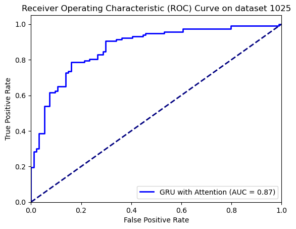

```python
from tensorflow.keras.layers import GRU, Attention, Input, Dense, Dropout
from tensorflow.keras.models import Model

# Define input_dim and timesteps based on your dataset
timesteps = X_train_reshaped.shape[1]
input_dim = X_train_reshaped.shape[2]

# GRU with Attention
inputs = Input(shape=(timesteps, input_dim))
gru_out = GRU(32, return_sequences=True)(inputs)
attention_out = Attention()([gru_out, gru_out])
dropout_out = Dropout(0.5)(attention_out)
gru_out_2 = GRU(16)(dropout_out)
dropout_out_2 = Dropout(0.5)(gru_out_2)
outputs = Dense(1, activation='sigmoid')(dropout_out_2)

model_gru_attention = Model(inputs, outputs)
model_gru_attention.compile(optimizer='adam', loss='binary_crossentropy', metrics=['accuracy'])

# Train the model
model_gru_attention.fit(X_train_reshaped, y_train, epochs=50, batch_size=32, validation_split=0.2)

# Predictions
y_pred_gru_attention = model_gru_attention.predict(X_test_reshaped).ravel()
y_pred_gru_attention_class = (y_pred_gru_attention > 0.5).astype(int)

# Evaluation
print("GRU with Attention on dataset 1025")
print(classification_report(y_test, y_pred_gru_attention_class))
roc_auc_gru_attention = roc_auc_score(y_test, y_pred_gru_attention)
print(f'ROC AUC: {roc_auc_gru_attention:.2f}')

# Plot the ROC curve
fpr_gru_attention, tpr_gru_attention, _ = roc_curve(y_test, y_pred_gru_attention)
plt.figure()
plt.plot(fpr_gru_attention, tpr_gru_attention, color='blue', lw=2, label=f'GRU with Attention (AUC = {roc_auc_gru_attention:.2f})')
plt.plot([0, 1], [0, 1], color='navy', lw=2, linestyle='--')
plt.xlim([0.0, 1.0])
plt.ylim([0.0, 1.05])
plt.xlabel('False Positive Rate')
plt.ylabel('True Positive Rate')
plt.title('Receiver Operating Characteristic (ROC) Curve on dataset 1025')
plt.legend(loc="lower right")
plt.show()
```

```
21/21 ━━━━━━━━━━━━━━━━━━━━ 1s 19ms/step - accuracy: 0.4787 - loss: 0.7171 - val_accuracy: 0.5503 - val_loss: 0.6856
21/21 ━━━━━━━━━━━━━━━━━━━━ 0s 2ms/step - accuracy: 0.5311 - loss: 0.6843 - val_accuracy: 0.5740 - val_loss: 0.6827
21/21 ━━━━━━━━━━━━━━━━━━━━ 0s 3ms/step - accuracy: 0.5295 - loss: 0.6935 - val_accuracy: 0.5325 - val_loss: 0.6796
21/21 ━━━━━━━━━━━━━━━━━━━━ 0s 2ms/step - accuracy: 0.5294 - loss: 0.6898 - val_accuracy: 0.5266 - val_loss: 0.6759
21/21 ━━━━━━━━━━━━━━━━━━━━ 0s 2ms/step - accuracy: 0.6111 - loss: 0.6651 - val_accuracy: 0.5444 - val_loss: 0.6690
21/21 ━━━━━━━━━━━━━━━━━━━━ 0s 2ms/step - accuracy: 0.6444 - loss: 0.6583 - val_accuracy: 0.5562 - val_loss: 0.6621
21/21 ━━━━━━━━━━━━━━━━━━━━ 0s 2ms/step - accuracy: 0.5990 - loss: 0.6713 - val_accuracy: 0.5976 - val_loss: 0.6553
21/21 ━━━━━━━━━━━━━━━━━━━━ 0s 2ms/step - accuracy: 0.5754 - loss: 0.6536 - val_accuracy: 0.6331 - val_loss: 0.6430
21/21 ━━━━━━━━━━━━━━━━━━━━ 0s 2ms/step - accuracy: 0.6090 - loss: 0.6466 - val_accuracy: 0.6864 - val_loss: 0.6278
21/21 ━━━━━━━━━━━━━━━━━━━━ 0s 2ms/step - accuracy: 0.6568 - loss: 0.6381 - val_accuracy: 0.6864 - val_loss: 0.6134
21/21 ━━━━━━━━━━━━━━━━━━━━ 0s 2ms/step - accuracy: 0.7020 - loss: 0.6093 - val_accuracy: 0.7337 - val_loss: 0.5953
21/21 ━━━━━━━━━━━━━━━━━━━━ 0s 2ms/step - accuracy: 0.7042 - loss: 0.5978 - val_accuracy: 0.7041 - val_loss: 0.5717
21/21 ━━━━━━━━━━━━━━━━━━━━ 0s 2ms/step - accuracy: 0.7196 - loss: 0.5637 - val_accuracy: 0.7219 - val_loss: 0.5593
21/21 ━━━━━━━━━━━━━━━━━━━━ 0s 2ms/step - accuracy: 0.7799 - loss: 0.5385 - val_accuracy: 0.7160 - val_loss: 0.5529
21/21 ━━━━━━━━━━━━━━━━━━━━ 0s 2ms/step - accuracy: 0.7315 - loss: 0.5585 - val_accuracy: 0.7278 - val_loss: 0.5479
21/21 ━━━━━━━━━━━━━━━━━━━━ 0s 2ms/step - accuracy: 0.7611 - loss: 0.5306 - val_accuracy: 0.7337 - val_loss: 0.5402
21/21 ━━━━━━━━━━━━━━━━━━━━ 0s 2ms/step - accuracy: 0.7991 - loss: 0.4841 - val_accuracy: 0.7574 - val_loss: 0.5368
21/21 ━━━━━━━━━━━━━━━━━━━━ 0s 3ms/step - accuracy: 0.7499 - loss: 0.5177 - val_accuracy: 0.7633 - val_loss: 0.5325
21/21 ━━━━━━━━━━━━━━━━━━━━ 0s 2ms/step - accuracy: 0.7723 - loss: 0.5277 - val_accuracy: 0.7692 - val_loss: 0.5305
21/21 ━━━━━━━━━━━━━━━━━━━━ 0s 3ms/step - accuracy: 0.7639 - loss: 0.5257 - val_accuracy: 0.7692 - val_loss: 0.5252
21/21 ━━━━━━━━━━━━━━━━━━━━ 0s 3ms/step - accuracy: 0.7509 - loss: 0.5382 - val_accuracy: 0.7811 - val_loss: 0.5216
21/21 ━━━━━━━━━━━━━━━━━━━━ 0s 3ms/step - accuracy: 0.7779 - loss: 0.5090 - val_accuracy: 0.7870 - val_loss: 0.5199
21/21 ━━━━━━━━━━━━━━━━━━━━ 0s 2ms/step - accuracy: 0.7596 - loss: 0.5300 - val_accuracy: 0.7692 - val_loss: 0.5172
21/21 ━━━━━━━━━━━━━━━━━━━━ 0s 2ms/step - accuracy: 0.7970 - loss: 0.4902 - val_accuracy: 0.7870 - val_loss: 0.5164
21/21 ━━━━━━━━━━━━━━━━━━━━ 0s 2ms/step - accuracy: 0.7776 - loss: 0.5239 - val_accuracy: 0.7870 - val_loss: 0.5092
21/21 ━━━━━━━━━━━━━━━━━━━━ 0s 3ms/step - accuracy: 0.7602 - loss: 0.5123 - val_accuracy: 0.7988 - val_loss: 0.5077
21/21 ━━━━━━━━━━━━━━━━━━━━ 0s 3ms/step - accuracy: 0.7573 - loss: 0.4951 - val_accuracy: 0.7751 - val_loss: 0.5084
21/21 ━━━━━━━━━━━━━━━━━━━━ 0s 2ms/step - accuracy: 0.7735 - loss: 0.4982 - val_accuracy: 0.7929 - val_loss: 0.5014
21/21 ━━━━━━━━━━━━━━━━━━━━ 0s 2ms/step - accuracy: 0.7688 - loss: 0.5041 - val_accuracy: 0.7870 - val_loss: 0.5044
21/21 ━━━━━━━━━━━━━━━━━━━━ 0s 2ms/step - accuracy: 0.7694 - loss: 0.4905 - val_accuracy: 0.7870 - val_loss: 0.5015
21/21 ━━━━━━━━━━━━━━━━━━━━ 0s 2ms/step - accuracy: 0.7763 - loss: 0.4761 - val_accuracy: 0.7811 - val_loss: 0.5018
21/21 ━━━━━━━━━━━━━━━━━━━━ 0s 2ms/step - accuracy: 0.7580 - loss: 0.4925 - val_accuracy: 0.7929 - val_loss: 0.4982
21/21 ━━━━━━━━━━━━━━━━━━━━ 0s 2ms/step - accuracy: 0.8154 - loss: 0.4411 - val_accuracy: 0.7870 - val_loss: 0.4993
21/21 ━━━━━━━━━━━━━━━━━━━━ 0s 2ms/step - accuracy: 0.8223 - loss: 0.4324 - val_accuracy: 0.7811 - val_loss: 0.4968
21/21 ━━━━━━━━━━━━━━━━━━━━ 0s 2ms/step - accuracy: 0.8122 - loss: 0.4435 - val_accuracy: 0.7751 - val_loss: 0.4984
21/21 ━━━━━━━━━━━━━━━━━━━━ 0s 2ms/step - accuracy: 0.7693 - loss: 0.5081 - val_accuracy: 0.7811 - val_loss: 0.4883
21/21 ━━━━━━━━━━━━━━━━━━━━ 0s 2ms/step - accuracy: 0.7785 - loss: 0.4765 - val_accuracy: 0.7929 - val_loss: 0.4947
21/21 ━━━━━━━━━━━━━━━━━━━━ 0s 2ms/step - accuracy: 0.7755 - loss: 0.5105 - val_accuracy: 0.7870 - val_loss: 0.4887
21/21 ━━━━━━━━━━━━━━━━━━━━ 0s 2ms/step - accuracy: 0.7899 - loss: 0.4919 - val_accuracy: 0.7692 - val_loss: 0.4875
21/21 ━━━━━━━━━━━━━━━━━━━━ 0s 2ms/step - accuracy: 0.7888 - loss: 0.4521 - val_accuracy: 0.7988 - val_loss: 0.4937
21/21 ━━━━━━━━━━━━━━━━━━━━ 0s 2ms/step - accuracy: 0.7947 - loss: 0.4636 - val_accuracy: 0.7870 - val_loss: 0.4943
```

[output cut: 21 more lines]

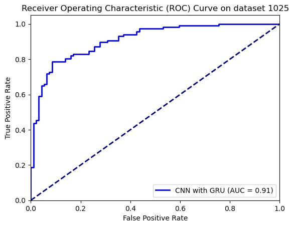

```python
from tensorflow.keras.layers import Conv1D, MaxPooling1D, GRU, Dense, Dropout, Flatten
from tensorflow.keras.models import Sequential

# Define input_dim and timesteps based on your dataset
timesteps = X_train_reshaped.shape[1]
input_dim = X_train_reshaped.shape[2]

# CNN with GRU
model_cnn_gru = Sequential([
    Conv1D(32, kernel_size=3, activation='relu', input_shape=(timesteps, input_dim)),
    MaxPooling1D(pool_size=2),
    Dropout(0.5),
    GRU(32, return_sequences=True),
    Dropout(0.5),
    GRU(16),
    Dropout(0.5),
    Dense(1, activation='sigmoid')
])

model_cnn_gru.compile(optimizer='adam', loss='binary_crossentropy', metrics=['accuracy'])

# Train the model
model_cnn_gru.fit(X_train_reshaped, y_train, epochs=50, batch_size=32, validation_split=0.2)

# Predictions
y_pred_cnn_gru = model_cnn_gru.predict(X_test_reshaped).ravel()
y_pred_cnn_gru_class = (y_pred_cnn_gru > 0.5).astype(int)

# Evaluation
print("CNN with GRU on dataset 1025")
print(classification_report(y_test, y_pred_cnn_gru_class))
roc_auc_cnn_gru = roc_auc_score(y_test, y_pred_cnn_gru)
print(f'ROC AUC: {roc_auc_cnn_gru:.2f}')

# Plot the ROC curve
fpr_cnn_gru, tpr_cnn_gru, _ = roc_curve(y_test, y_pred_cnn_gru)
plt.figure()
plt.plot(fpr_cnn_gru, tpr_cnn_gru, color='blue', lw=2, label=f'CNN with GRU (AUC = {roc_auc_cnn_gru:.2f})')
plt.plot([0, 1], [0, 1], color='navy', lw=2, linestyle='--')
plt.xlim([0.0, 1.0])
plt.ylim([0.0, 1.05])
plt.xlabel('False Positive Rate')
plt.ylabel('True Positive Rate')
plt.title('Receiver Operating Characteristic (ROC) Curve on dataset 1025')
plt.legend(loc="lower right")
plt.show()
```

```python
# Reshape the input data
import numpy as np

# Assuming X_train and X_test are your original features
X_train_cnn = np.expand_dims(X_train, axis=-1)  # Adding the last dimension for features
X_test_cnn = np.expand_dims(X_test, axis=-1)

print(X_train_cnn.shape)  # Should print (number of samples, 15, 1)
print(X_test_cnn.shape)
```

```
(841, 13, 1)
(211, 13, 1)
```

```python
# Comparison and Analysis
# Summarize all ROC AUC scores
roc_auc_scores = {
    'Logistic Regression': roc_auc_lr,
    'Support Vector Machine': roc_auc_svm,
    'Random Forest': roc_auc_rf,
    'Gradient Boosting Machine': roc_auc_gbm,
    'XGBoost Classifier': roc_auc_xgbm,
    'Simple Neural Network': roc_auc_nn,
    'Convolutional Neural Network': roc_auc_cnn,
    'GRU with Attention': roc_auc_gru_attention,
    'CNN with GRU': roc_auc_cnn_gru
}

# Print all ROC AUC scores
for model, score in roc_auc_scores.items():
    print(f'{model}: ROC AUC = {score:.2f}')
```

```
Logistic Regression: ROC AUC = 0.91
Support Vector Machine: ROC AUC = 0.91
Random Forest: ROC AUC = 0.95
Gradient Boosting Machine: ROC AUC = 0.97
XGBoost Classifier: ROC AUC = 0.98
Simple Neural Network: ROC AUC = 0.94
Convolutional Neural Network: ROC AUC = 0.93
GRU with Attention: ROC AUC = 0.87
CNN with GRU: ROC AUC = 0.91
```

```python
data.columns
```

```
Index(['age', 'sex', 'cp', 'trestbps', 'chol', 'fbs', 'restecg', 'thalach',
       'exang', 'oldpeak', 'slope', 'ca', 'thal', 'target'],
      dtype='object')
```

```
Random Forest Feature Importances on 1025 dataset
     Feature  Importance
2         cp    0.137624
9    oldpeak    0.125481
11        ca    0.123864
7    thalach    0.114188
12      thal    0.099160
0        age    0.091996
4       chol    0.079055
3   trestbps    0.077611
10     slope    0.044919
8      exang    0.044425
1        sex    0.034099
6    restecg    0.018417
5        fbs    0.009161
```

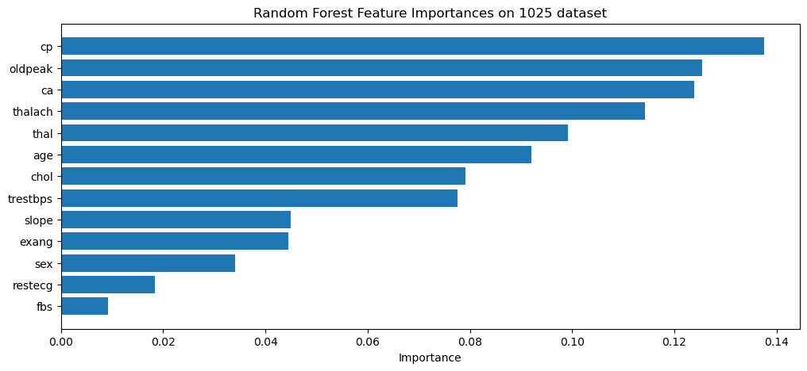

```python
# FEATURE IMPORTANCES

import pandas as pd
from imblearn.over_sampling import SMOTE
from sklearn.model_selection import train_test_split
from sklearn.preprocessing import StandardScaler
from sklearn.ensemble import RandomForestClassifier
import matplotlib.pyplot as plt

# Load dataset loaded

# Fill missing values with mean values
# data.fillna(data.mean(), inplace=True)

# Define features and target - defined

# Apply SMOTE to balance the dataset
smote = SMOTE(random_state=42)
X_resampled, y_resampled = smote.fit_resample(X, y)

# Split data into training and testing sets
X_train, X_test, y_train, y_test = train_test_split(X_resampled, y_resampled, test_size=0.2, random_state=42)

# Scale features
scaler = StandardScaler()
X_train = scaler.fit_transform(X_train)
X_test = scaler.transform(X_test)

# Train a Random Forest model
rf = RandomForestClassifier(random_state=42)
rf.fit(X_train, y_train)

# FEATURE IMPORTANCES
# Get feature importances from the Random Forest model
feature_importances_rf = rf.feature_importances_

# Create a DataFrame for feature importances
features = X.columns
importance_df_rf = pd.DataFrame({'Feature': features, 'Importance': feature_importances_rf})

# Sort the DataFrame by importance
importance_df_rf = importance_df_rf.sort_values(by='Importance', ascending=False)

# Print the feature importances
print("Random Forest Feature Importances on 1025 dataset")
print(importance_df_rf)

# Plot the feature importances
plt.figure(figsize=(12, 5))
plt.barh(importance_df_rf['Feature'], importance_df_rf['Importance'])
plt.gca().invert_yaxis()
plt.xlabel('Importance')
plt.title('Random Forest Feature Importances on 1025 dataset')
plt.show()
```

```
Random Forest Feature Importances
     Feature  Importance
2         cp    0.137624
9    oldpeak    0.125481
11        ca    0.123864
7    thalach    0.114188
12      thal    0.099160
0        age    0.091996
4       chol    0.079055
3   trestbps    0.077611
10     slope    0.044919
8      exang    0.044425
1        sex    0.034099
6    restecg    0.018417
5        fbs    0.009161
```

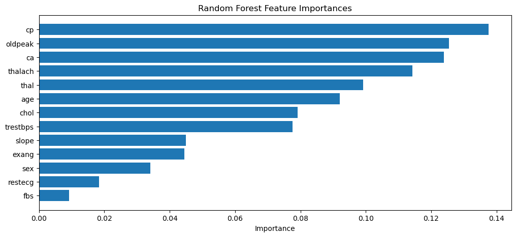

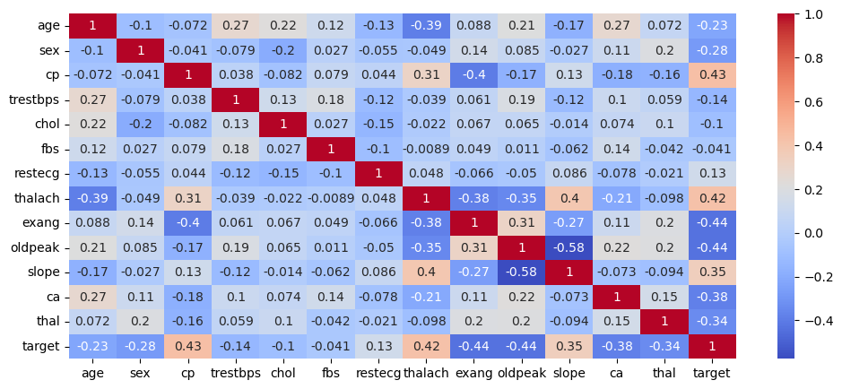

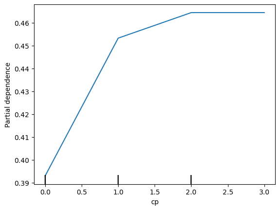

```python
# ALL THREE IN ONE PLACE
import pandas as pd
import matplotlib.pyplot as plt
from imblearn.over_sampling import SMOTE
from sklearn.model_selection import train_test_split
from sklearn.preprocessing import StandardScaler
from sklearn.ensemble import RandomForestClassifier
from sklearn.inspection import PartialDependenceDisplay
import seaborn as sns

# Load dataset - loaded

# Fill missing values with mean values - completed

# Define features and target - defined

# Apply SMOTE to balance the dataset
smote = SMOTE(random_state=42)
X_resampled, y_resampled = smote.fit_resample(X, y)

# Split data into training and testing sets
X_train, X_test, y_train, y_test = train_test_split(X_resampled, y_resampled, test_size=0.2, random_state=42)

# Scale features
scaler = StandardScaler()
X_train = scaler.fit_transform(X_train)
X_test = scaler.transform(X_test)

# Train a Random Forest model
rf = RandomForestClassifier(random_state=42)
rf.fit(X_train, y_train)

# FEATURE IMPORTANCES
# Get feature importances from the Random Forest model
feature_importances_rf = rf.feature_importances_

# Create a DataFrame for feature importances
features = X.columns
importance_df_rf = pd.DataFrame({'Feature': features, 'Importance': feature_importances_rf})

# Sort the DataFrame by importance
importance_df_rf = importance_df_rf.sort_values(by='Importance', ascending=False)

# Print the feature importances
print("Random Forest Feature Importances")
print(importance_df_rf)

# Plot the feature importances
plt.figure(figsize=(12, 5))
plt.barh(importance_df_rf['Feature'], importance_df_rf['Importance'])
plt.gca().invert_yaxis()
plt.xlabel('Importance')
plt.title('Random Forest Feature Importances')
plt.show()

# Correlation Analysis
# Calculate correlation matrix
corr_matrix = data[['age', 'sex', 'cp', 'trestbps', 'chol', 'fbs', 'restecg', 'thalach',
       'exang', 'oldpeak', 'slope', 'ca', 'thal','target']].corr()

# Plot heatmap
plt.figure(figsize=(12, 5))
sns.heatmap(corr_matrix, annot=True, cmap='coolwarm')
plt.show()

# Partial Dependence Plots: Visualize the relationship between "education" and the target variable while accounting for the average effect of other features
features = ['cp']  # List of features for which to plot partial dependence

PartialDependenceDisplay.from_estimator(rf, X, features)
plt.show()
```

## STACKING MODELS implementation

```python
import pandas as pd
from imblearn.over_sampling import SMOTE
from sklearn.model_selection import train_test_split
from sklearn.preprocessing import StandardScaler
from sklearn.svm import SVC
from sklearn.ensemble import RandomForestClassifier
from sklearn.ensemble import GradientBoostingClassifier
from xgboost import XGBClassifier
from sklearn.linear_model import LogisticRegression
from sklearn.metrics import classification_report, roc_auc_score, roc_curve

# Load dataset loaded previous
# data = pd.read_csv('hf_cleveland_303.csv')

# fill missing values with mean values
# data.fillna(data.mean(), inplace=True)

# Define features and target - done

# Apply SMOTE to balance the dataset
smote = SMOTE(random_state=42)
X_resampled, y_resampled = smote.fit_resample(X, y)

# Split data
X_train, X_test, y_train, y_test = train_test_split(X_resampled, y_resampled, test_size=0.2, random_state=42)

# Scale features
scaler = StandardScaler()
X_train = scaler.fit_transform(X_train)
X_test = scaler.transform(X_test)

# Logistic Regression
log_reg = LogisticRegression(C=1.0, penalty='l2', solver='liblinear', random_state=42)
log_reg.fit(X_train, y_train)

# Predictions
y_pred_lr = log_reg.predict(X_test)
y_proba_lr = log_reg.predict_proba(X_test)[:, 1]

# Evaluation
print("Logistic Regression on 1025 dataset")
print(classification_report(y_test, y_pred_lr))
roc_auc_lr = roc_auc_score(y_test, y_proba_lr)
print(f'ROC AUC: {roc_auc_lr:.2f}')
print("-------------------------------------------------------")

# Support Vector Machine
svm = SVC(C=1.0, kernel='linear', probability=True, random_state=42)
svm.fit(X_train, y_train)

# Predictions
y_pred_svm = svm.predict(X_test)
y_proba_svm = svm.predict_proba(X_test)[:, 1]

# Evaluation
print("Support Vector Machine on 1025 dataset")
print(classification_report(y_test, y_pred_svm))
roc_auc_svm = roc_auc_score(y_test, y_proba_svm)
print(f'ROC AUC - 1025 dataset: {roc_auc_svm:.2f}')
print("-------------------------------------------------------")

# Random Forest
rf = RandomForestClassifier(max_depth=3, n_estimators=30, min_samples_leaf=5, random_state=42)
rf.fit(X_train, y_train)

# Predictions
y_pred_rf = rf.predict(X_test)
y_proba_rf = rf.predict_proba(X_test)[:, 1]

# Evaluation
print("Random Forest on 1025 dataset")
print(classification_report(y_test, y_pred_rf))
roc_auc_rf = roc_auc_score(y_test, y_proba_rf)
print(f'ROC AUC - 1025 dataset: {roc_auc_rf:.2f}')
print("-------------------------------------------------------")

# Gradient Boosting Machine
gbm = GradientBoostingClassifier(max_depth=3, n_estimators=30, min_samples_leaf=5, random_state=42)
gbm.fit(X_train, y_train)

# Predictions
y_pred_gbm = gbm.predict(X_test)
y_proba_gbm = gbm.predict_proba(X_test)[:, 1]

# Evaluation
print("Gradient Boosting Machine on 1025 dataset")
print(classification_report(y_test, y_pred_gbm))
roc_auc_gbm = roc_auc_score(y_test, y_proba_gbm)
print(f'ROC AUC - 1025 dataset: {roc_auc_gbm:.2f}')
print("-------------------------------------------------------")

# XGBoost Classifier
xgbm = XGBClassifier(max_depth=3, min_child_weight=10, subsample=0.7, colsample_bytree=0.7, random_state=42)
xgbm.fit(X_train, y_train)

# Predictions
y_pred_xgbm = xgbm.predict(X_test)
y_proba_xgbm = xgbm.predict_proba(X_test)[:, 1]

# Evaluation
print("XGBoost on 1025 dataset")
print(classification_report(y_test, y_pred_xgbm))
roc_auc_xgbm = roc_auc_score(y_test, y_proba_xgbm)
print(f'ROC AUC - 1025 dataset: {roc_auc_xgbm:.2f}')
```

```
Logistic Regression on 1025 dataset
              precision    recall  f1-score   support

           0       0.84      0.76      0.79        94
           1       0.82      0.88      0.85       117

    accuracy                           0.82       211
   macro avg       0.83      0.82      0.82       211
weighted avg       0.83      0.82      0.82       211

ROC AUC: 0.91
-------------------------------------------------------
Support Vector Machine on 1025 dataset
              precision    recall  f1-score   support

           0       0.82      0.73      0.78        94
           1       0.80      0.87      0.84       117

    accuracy                           0.81       211
   macro avg       0.81      0.80      0.81       211
weighted avg       0.81      0.81      0.81       211

ROC AUC - 1025 dataset: 0.91
-------------------------------------------------------
Random Forest on 1025 dataset
              precision    recall  f1-score   support

           0       0.92      0.88      0.90        94
           1       0.91      0.94      0.92       117

    accuracy                           0.91       211
   macro avg       0.92      0.91      0.91       211
weighted avg       0.91      0.91      0.91       211

ROC AUC - 1025 dataset: 0.95
-------------------------------------------------------
Gradient Boosting Machine on 1025 dataset
              precision    recall  f1-score   support

           0       0.93      0.87      0.90        94
           1       0.90      0.95      0.93       117

    accuracy                           0.91       211
   macro avg       0.92      0.91      0.91       211
weighted avg       0.92      0.91      0.91       211

ROC AUC - 1025 dataset: 0.97
-------------------------------------------------------
XGBoost on 1025 dataset
              precision    recall  f1-score   support

           0       0.91      0.93      0.92        94
           1       0.94      0.92      0.93       117

    accuracy                           0.92       211
   macro avg       0.92      0.92      0.92       211
weighted avg       0.92      0.92      0.92       211

ROC AUC - 1025 dataset: 0.98
```

```python
!pip install seaborn
```

```python
# Cross-Validation to ensure that the model's performance is consistent across different subsets of the data.
from sklearn.model_selection import cross_val_score

rf = RandomForestClassifier(random_state=42)
xgb = XGBClassifier(random_state=42)

rf_scores = cross_val_score(rf, X_train, y_train, cv=5, scoring='accuracy')
xgb_scores = cross_val_score(xgb, X_train, y_train, cv=5, scoring='accuracy')

print("Random Forest Cross-Validation Scores:", rf_scores)
print("XGBoost Cross-Validation Scores:", xgb_scores)
```

```
Random Forest Cross-Validation Scores: [0.97633136 0.98809524 0.99404762 0.98809524 0.98809524]
XGBoost Cross-Validation Scores: [0.97633136 0.98809524 0.98214286 0.98214286 0.99404762]
```

**Add regularization to the models to penalize complexity. For Random Forest, limit the depth of the trees or the number of features considered at each split. For XGBoost, use parameters like max_depth, min_child_weight, and subsample.**

[output not shown]

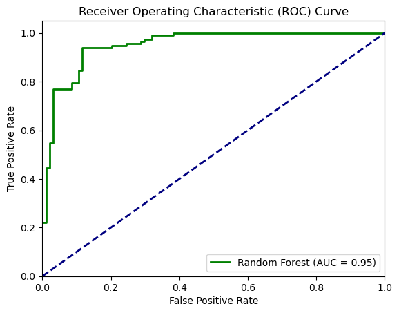

[output not shown]

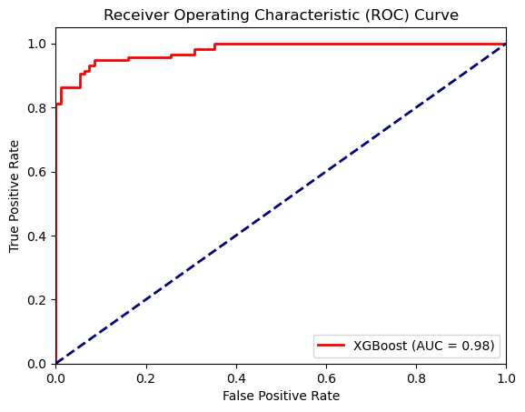

```python
from sklearn.metrics import classification_report, roc_auc_score, roc_curve
import matplotlib.pyplot as plt

# Train the Random Forest model
rf.fit(X_train, y_train)
y_pred_rf = rf.predict(X_test)
y_proba_rf = rf.predict_proba(X_test)[:, 1]

# Print evaluation metrics for Random Forest
print("Random Forest on 1025 dataset")
print(classification_report(y_test, y_pred_rf))
roc_auc_rf = roc_auc_score(y_test, y_proba_rf)
print(f'ROC AUC - 1025 dataset: {roc_auc_rf:.2f}')

# Plot the ROC curve for Random Forest
fpr_rf, tpr_rf, _ = roc_curve(y_test, y_proba_rf)
plt.figure()
plt.plot(fpr_rf, tpr_rf, color='green', lw=2, label=f'Random Forest (AUC = {roc_auc_rf:.2f})')
plt.plot([0, 1], [0, 1], color='navy', lw=2, linestyle='--')
plt.xlim([0.0, 1.0])
plt.ylim([0.0, 1.05])
plt.xlabel('False Positive Rate')
plt.ylabel('True Positive Rate')
plt.title('Receiver Operating Characteristic (ROC) Curve')
plt.legend(loc="lower right")
plt.show()

# Train the XGBoost model
xgb.fit(X_train, y_train)
y_pred_xgb = xgb.predict(X_test)
y_proba_xgb = xgb.predict_proba(X_test)[:, 1]

# Print evaluation metrics for XGBoost
print("XGBoost on 1025 dataset")
print(classification_report(y_test, y_pred_xgb))
roc_auc_xgb = roc_auc_score(y_test, y_proba_xgb)
print(f'ROC AUC - 1025 dataset: {roc_auc_xgb:.2f}')

# Plot the ROC curve for XGBoost
fpr_xgb, tpr_xgb, _ = roc_curve(y_test, y_proba_xgb)
plt.figure()
plt.plot(fpr_xgb, tpr_xgb, color='red', lw=2, label=f'XGBoost (AUC = {roc_auc_xgb:.2f})')
plt.plot([0, 1], [0, 1], color='navy', lw=2, linestyle='--')
plt.xlim([0.0, 1.0])
plt.ylim([0.0, 1.05])
plt.xlabel('False Positive Rate')
plt.ylabel('True Positive Rate')
plt.title('Receiver Operating Characteristic (ROC) Curve')
plt.legend(loc="lower right")
plt.show()
```

```
Stacking Ensemble of RF + GBM + xGBM on 1025 dataset
              precision    recall  f1-score   support

           0       0.91      0.94      0.92        94
           1       0.95      0.92      0.94       117

    accuracy                           0.93       211
   macro avg       0.93      0.93      0.93       211
weighted avg       0.93      0.93      0.93       211

ROC AUC - 1025 dataset: 0.98
```

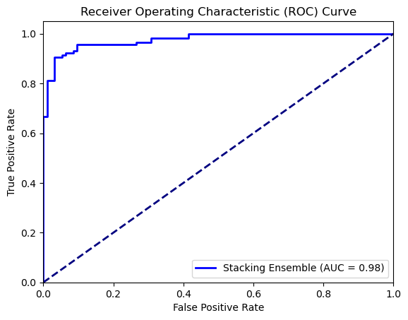

```python
# STACKING MODELS - RF + GBM + xGBM

from sklearn.ensemble import StackingClassifier
from sklearn.linear_model import LogisticRegression
from sklearn.model_selection import cross_val_score
from sklearn.metrics import classification_report, roc_auc_score, roc_curve

# Define the base models
base_models = [
    ('rf', RandomForestClassifier(max_depth=3, n_estimators=30, min_samples_leaf=5, random_state=42)),
    ('gbm', GradientBoostingClassifier(max_depth=3, n_estimators=30, min_samples_leaf=5, random_state=42)),
    ('xgb', XGBClassifier(max_depth=3, min_child_weight=10, subsample=0.7, colsample_bytree=0.7, random_state=42))
]

# Define the meta-learner model
meta_model = LogisticRegression()

# Create the stacking ensemble
stacking_clf = StackingClassifier(estimators=base_models, final_estimator=meta_model, cv=5)

# Train the stacking ensemble
stacking_clf.fit(X_train, y_train)

# Evaluate the stacking ensemble
y_pred_stack = stacking_clf.predict(X_test)
y_proba_stack = stacking_clf.predict_proba(X_test)[:, 1]

# Print evaluation metrics
print("Stacking Ensemble of RF + GBM + xGBM on 1025 dataset")
print(classification_report(y_test, y_pred_stack))
roc_auc_stack = roc_auc_score(y_test, y_proba_stack)
print(f'ROC AUC - 1025 dataset: {roc_auc_stack:.2f}')

# Plot the ROC curve
fpr, tpr, _ = roc_curve(y_test, y_proba_stack)
plt.figure()
plt.plot(fpr, tpr, color='blue', lw=2, label=f'Stacking Ensemble (AUC = {roc_auc_stack:.2f})')
plt.plot([0, 1], [0, 1], color='navy', lw=2, linestyle='--')
plt.xlim([0.0, 1.0])
plt.ylim([0.0, 1.05])
plt.xlabel('False Positive Rate')
plt.ylabel('True Positive Rate')
plt.title('Receiver Operating Characteristic (ROC) Curve')
plt.legend(loc="lower right")
plt.show()
```

```
Stacking Ensemble RF + XGBM + SVM on 1025 dataset
              precision    recall  f1-score   support

           0       0.91      0.93      0.92        94
           1       0.94      0.92      0.93       117

    accuracy                           0.92       211
   macro avg       0.92      0.92      0.92       211
weighted avg       0.92      0.92      0.92       211

ROC AUC on 1025 dataset: 0.98
```

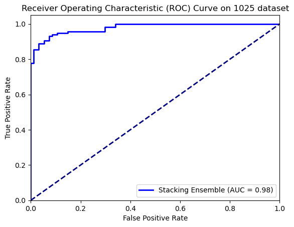

```python
# STACKING MODELS - RF + xGBM + SVM

from sklearn.ensemble import StackingClassifier
from sklearn.linear_model import LogisticRegression
from sklearn.model_selection import cross_val_score

# Define the base models
base_models = [
    ('rf', RandomForestClassifier(max_depth=3, n_estimators=30, min_samples_leaf=5, random_state=42)),
    ('svm', SVC(C=1.0, kernel='linear', probability=True, random_state=42)),
    ('xgb', XGBClassifier(max_depth=3, min_child_weight=10, subsample=0.7, colsample_bytree=0.7, random_state=42))
]

# Define the meta-learner model
meta_model = LogisticRegression()

# Create the stacking ensemble
stacking_clf = StackingClassifier(estimators=base_models, final_estimator=meta_model, cv=5)

# Train the stacking ensemble
stacking_clf.fit(X_train, y_train)

# Evaluate the stacking ensemble
y_pred_stack = stacking_clf.predict(X_test)
y_proba_stack = stacking_clf.predict_proba(X_test)[:, 1]

# Print evaluation metrics
print("Stacking Ensemble RF + XGBM + SVM on 1025 dataset")
print(classification_report(y_test, y_pred_stack))
roc_auc_stack = roc_auc_score(y_test, y_proba_stack)
print(f'ROC AUC on 1025 dataset: {roc_auc_stack:.2f}')

# Plot the ROC curve
fpr, tpr, _ = roc_curve(y_test, y_proba_stack)
plt.figure()
plt.plot(fpr, tpr, color='blue', lw=2, label=f'Stacking Ensemble (AUC = {roc_auc_stack:.2f})')
plt.plot([0, 1], [0, 1], color='navy', lw=2, linestyle='--')
plt.xlim([0.0, 1.0])
plt.ylim([0.0, 1.05])
plt.xlabel('False Positive Rate')
plt.ylabel('True Positive Rate')
plt.title('Receiver Operating Characteristic (ROC) Curve on 1025 dataset')
plt.legend(loc="lower right")
plt.show()
```

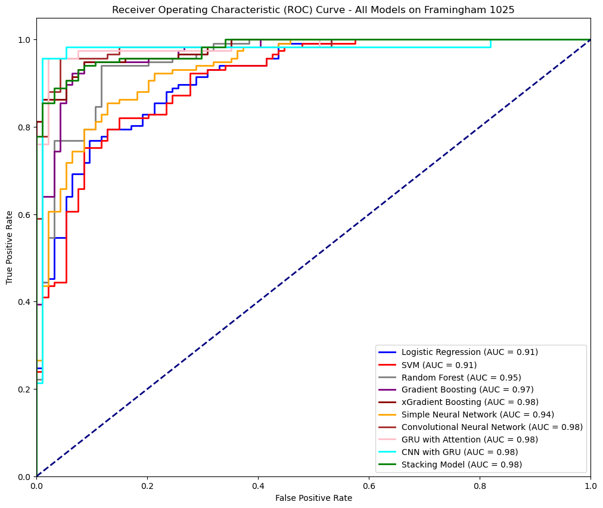

```python
# ALL ROC Curve in one place

import matplotlib.pyplot as plt
from sklearn.metrics import roc_curve, roc_auc_score

# Calculate ROC curve and AUC for each updated model
fpr_lr, tpr_lr, _ = roc_curve(y_test, y_proba_lr)
roc_auc_lr = roc_auc_score(y_test, y_proba_lr)

fpr_svm, tpr_svm, _ = roc_curve(y_test, y_proba_svm)
roc_auc_svm = roc_auc_score(y_test, y_proba_svm)

fpr_rf, tpr_rf, _ = roc_curve(y_test, y_proba_rf)
roc_auc_rf = roc_auc_score(y_test, y_proba_rf)

fpr_gbm, tpr_gbm, _ = roc_curve(y_test, y_proba_gbm)
roc_auc_gbm = roc_auc_score(y_test, y_proba_gbm)

fpr_xgbm, tpr_xgbm, _ = roc_curve(y_test, y_proba_xgbm)
roc_auc_xgbm = roc_auc_score(y_test, y_proba_xgbm)

fpr_nn, tpr_nn, _ = roc_curve(y_test, y_proba_nn)
roc_auc_nn = roc_auc_score(y_test, y_proba_nn)

fpr_cnn, tpr_cnn, _ = roc_curve(y_test, y_proba_cnn)
roc_auc_cnn = roc_auc_score(y_test, y_proba_cnn)

fpr_gru_attention, tpr_gru_attention, _ = roc_curve(y_test, y_proba_gru_attention)
roc_auc_gru_attention = roc_auc_score(y_test, y_proba_gru_attention)

fpr_cnn_gru, tpr_cnn_gru, _ = roc_curve(y_test, y_proba_cnn_gru)
roc_auc_cnn_gru = roc_auc_score(y_test, y_proba_cnn_gru)

fpr, tpr, _ = roc_curve(y_test, y_proba_stack)
roc_auc_stack = roc_auc_score(y_test, y_proba_stack)

# Plot all ROC curves on the same plot
#plt.figure()
fig, ax = plt.subplots(figsize=(12, 10))

plt.plot(fpr_lr, tpr_lr, color='blue', lw=2, label=f'Logistic Regression (AUC = {roc_auc_lr:.2f})')
plt.plot(fpr_svm, tpr_svm, color='red', lw=2, label=f'SVM (AUC = {roc_auc_svm:.2f})')
plt.plot(fpr_rf, tpr_rf, color='gray', lw=2, label=f'Random Forest (AUC = {roc_auc_rf:.2f})')
plt.plot(fpr_gbm, tpr_gbm, color='purple', lw=2, label=f'Gradient Boosting (AUC = {roc_auc_gbm:.2f})')
plt.plot(fpr_xgbm, tpr_xgbm, color='darkred', lw=2, label=f'xGradient Boosting (AUC = {roc_auc_xgbm:.2f})')
plt.plot(fpr_nn, tpr_nn, color='orange', lw=2, label=f'Simple Neural Network (AUC = {roc_auc_nn:.2f})')
plt.plot(fpr_cnn, tpr_cnn, color='brown', lw=2, label=f'Convolutional Neural Network (AUC = {roc_auc_cnn:.2f})')
plt.plot(fpr_gru_attention, tpr_gru_attention, color='pink', lw=2, label=f'GRU with Attention (AUC = {roc_auc_gru_attention:.2f})')
plt.plot(fpr_cnn_gru, tpr_cnn_gru, color='cyan', lw=2, label=f'CNN with GRU (AUC = {roc_auc_cnn_gru:.2f})')
plt.plot(fpr, tpr, color='green', lw=2, label=f'Stacking Model (AUC = {roc_auc_stack:.2f})')

plt.plot([0, 1], [0, 1], color='navy', lw=2, linestyle='--')
plt.xlim([0.0, 1.0])
plt.ylim([0.0, 1.05])
plt.xlabel('False Positive Rate')
plt.ylabel('True Positive Rate')
plt.title('Receiver Operating Characteristic (ROC) Curve - All Models on Framingham 1025')
plt.legend(loc="lower right")
plt.show()
```

## STACKING MODELS RF + xGBM + SVM + CNN

```
21/21 ━━━━━━━━━━━━━━━━━━━━ 0s 4ms/step - accuracy: 0.5360 - loss: 0.6842 - val_accuracy: 0.7870 - val_loss: 0.5223
21/21 ━━━━━━━━━━━━━━━━━━━━ 0s 1ms/step - accuracy: 0.8306 - loss: 0.4586 - val_accuracy: 0.7988 - val_loss: 0.4608
21/21 ━━━━━━━━━━━━━━━━━━━━ 0s 1ms/step - accuracy: 0.8428 - loss: 0.3796 - val_accuracy: 0.7870 - val_loss: 0.4578
21/21 ━━━━━━━━━━━━━━━━━━━━ 0s 1ms/step - accuracy: 0.8474 - loss: 0.3481 - val_accuracy: 0.7929 - val_loss: 0.4433
21/21 ━━━━━━━━━━━━━━━━━━━━ 0s 1ms/step - accuracy: 0.8520 - loss: 0.3379 - val_accuracy: 0.7811 - val_loss: 0.4465
21/21 ━━━━━━━━━━━━━━━━━━━━ 0s 1ms/step - accuracy: 0.8492 - loss: 0.3528 - val_accuracy: 0.7929 - val_loss: 0.4347
21/21 ━━━━━━━━━━━━━━━━━━━━ 0s 1ms/step - accuracy: 0.8718 - loss: 0.3204 - val_accuracy: 0.7929 - val_loss: 0.4291
21/21 ━━━━━━━━━━━━━━━━━━━━ 0s 1ms/step - accuracy: 0.8401 - loss: 0.3594 - val_accuracy: 0.7988 - val_loss: 0.4227
21/21 ━━━━━━━━━━━━━━━━━━━━ 0s 1ms/step - accuracy: 0.8465 - loss: 0.3281 - val_accuracy: 0.8047 - val_loss: 0.4263
21/21 ━━━━━━━━━━━━━━━━━━━━ 0s 1ms/step - accuracy: 0.8358 - loss: 0.3347 - val_accuracy: 0.8284 - val_loss: 0.4366
21/21 ━━━━━━━━━━━━━━━━━━━━ 0s 1ms/step - accuracy: 0.8770 - loss: 0.3075 - val_accuracy: 0.7870 - val_loss: 0.4195
21/21 ━━━━━━━━━━━━━━━━━━━━ 0s 1ms/step - accuracy: 0.8339 - loss: 0.3267 - val_accuracy: 0.8166 - val_loss: 0.4037
21/21 ━━━━━━━━━━━━━━━━━━━━ 0s 1ms/step - accuracy: 0.8649 - loss: 0.2812 - val_accuracy: 0.7988 - val_loss: 0.4033
21/21 ━━━━━━━━━━━━━━━━━━━━ 0s 1ms/step - accuracy: 0.8662 - loss: 0.2726 - val_accuracy: 0.8343 - val_loss: 0.4123
21/21 ━━━━━━━━━━━━━━━━━━━━ 0s 1ms/step - accuracy: 0.8856 - loss: 0.2762 - val_accuracy: 0.7988 - val_loss: 0.3889
21/21 ━━━━━━━━━━━━━━━━━━━━ 0s 1ms/step - accuracy: 0.8699 - loss: 0.2568 - val_accuracy: 0.8225 - val_loss: 0.3796
21/21 ━━━━━━━━━━━━━━━━━━━━ 0s 1ms/step - accuracy: 0.8690 - loss: 0.2543 - val_accuracy: 0.8284 - val_loss: 0.3825
21/21 ━━━━━━━━━━━━━━━━━━━━ 0s 1ms/step - accuracy: 0.8798 - loss: 0.2696 - val_accuracy: 0.8284 - val_loss: 0.3663
21/21 ━━━━━━━━━━━━━━━━━━━━ 0s 1ms/step - accuracy: 0.8954 - loss: 0.2463 - val_accuracy: 0.8462 - val_loss: 0.3627
21/21 ━━━━━━━━━━━━━━━━━━━━ 0s 1ms/step - accuracy: 0.8882 - loss: 0.2414 - val_accuracy: 0.8580 - val_loss: 0.3566
21/21 ━━━━━━━━━━━━━━━━━━━━ 0s 1ms/step - accuracy: 0.8940 - loss: 0.2295 - val_accuracy: 0.8521 - val_loss: 0.3528
21/21 ━━━━━━━━━━━━━━━━━━━━ 0s 1ms/step - accuracy: 0.8838 - loss: 0.2489 - val_accuracy: 0.8698 - val_loss: 0.3389
21/21 ━━━━━━━━━━━━━━━━━━━━ 0s 1ms/step - accuracy: 0.8802 - loss: 0.2363 - val_accuracy: 0.8817 - val_loss: 0.3354
21/21 ━━━━━━━━━━━━━━━━━━━━ 0s 1ms/step - accuracy: 0.9215 - loss: 0.1908 - val_accuracy: 0.8817 - val_loss: 0.3282
21/21 ━━━━━━━━━━━━━━━━━━━━ 0s 1ms/step - accuracy: 0.9196 - loss: 0.2008 - val_accuracy: 0.8876 - val_loss: 0.3215
21/21 ━━━━━━━━━━━━━━━━━━━━ 0s 1ms/step - accuracy: 0.9386 - loss: 0.1832 - val_accuracy: 0.8757 - val_loss: 0.3195
21/21 ━━━━━━━━━━━━━━━━━━━━ 0s 1ms/step - accuracy: 0.9341 - loss: 0.2060 - val_accuracy: 0.9112 - val_loss: 0.3122
21/21 ━━━━━━━━━━━━━━━━━━━━ 0s 1ms/step - accuracy: 0.9498 - loss: 0.1658 - val_accuracy: 0.8698 - val_loss: 0.3148
21/21 ━━━━━━━━━━━━━━━━━━━━ 0s 1ms/step - accuracy: 0.9370 - loss: 0.1673 - val_accuracy: 0.8757 - val_loss: 0.3018
21/21 ━━━━━━━━━━━━━━━━━━━━ 0s 1ms/step - accuracy: 0.9393 - loss: 0.1845 - val_accuracy: 0.8876 - val_loss: 0.2890
21/21 ━━━━━━━━━━━━━━━━━━━━ 0s 1ms/step - accuracy: 0.9483 - loss: 0.1569 - val_accuracy: 0.9053 - val_loss: 0.2993
21/21 ━━━━━━━━━━━━━━━━━━━━ 0s 1ms/step - accuracy: 0.9534 - loss: 0.1521 - val_accuracy: 0.8817 - val_loss: 0.2979
21/21 ━━━━━━━━━━━━━━━━━━━━ 0s 1ms/step - accuracy: 0.9394 - loss: 0.1784 - val_accuracy: 0.9112 - val_loss: 0.2720
21/21 ━━━━━━━━━━━━━━━━━━━━ 0s 1ms/step - accuracy: 0.9601 - loss: 0.1505 - val_accuracy: 0.9053 - val_loss: 0.2744
21/21 ━━━━━━━━━━━━━━━━━━━━ 0s 1ms/step - accuracy: 0.9578 - loss: 0.1377 - val_accuracy: 0.9172 - val_loss: 0.2645
21/21 ━━━━━━━━━━━━━━━━━━━━ 0s 1ms/step - accuracy: 0.9746 - loss: 0.1348 - val_accuracy: 0.9349 - val_loss: 0.2586
21/21 ━━━━━━━━━━━━━━━━━━━━ 0s 1ms/step - accuracy: 0.9753 - loss: 0.1232 - val_accuracy: 0.9231 - val_loss: 0.2502
21/21 ━━━━━━━━━━━━━━━━━━━━ 0s 1ms/step - accuracy: 0.9574 - loss: 0.1494 - val_accuracy: 0.9231 - val_loss: 0.2458
21/21 ━━━━━━━━━━━━━━━━━━━━ 0s 1ms/step - accuracy: 0.9746 - loss: 0.1219 - val_accuracy: 0.9172 - val_loss: 0.2539
21/21 ━━━━━━━━━━━━━━━━━━━━ 0s 1ms/step - accuracy: 0.9697 - loss: 0.1246 - val_accuracy: 0.9290 - val_loss: 0.2357
```

[output cut: 8 more lines]

```
21/21 ━━━━━━━━━━━━━━━━━━━━ 0s 1ms/step - accuracy: 0.9875 - loss: 0.0842 - val_accuracy: 0.9527 - val_loss: 0.2010
21/21 ━━━━━━━━━━━━━━━━━━━━ 0s 1ms/step - accuracy: 0.9844 - loss: 0.0844 - val_accuracy: 0.9527 - val_loss: 0.1826
27/27 ━━━━━━━━━━━━━━━━━━━━ 0s 936us/step
7/7 ━━━━━━━━━━━━━━━━━━━━ 0s 433us/step
Stacking Ensemble with RF + xGBM + SVM. + CNN on 1025 dataset
              precision    recall  f1-score   support

           0       0.94      0.95      0.94        94
           1       0.96      0.95      0.95       117

    accuracy                           0.95       211
   macro avg       0.95      0.95      0.95       211
weighted avg       0.95      0.95      0.95       211

ROC AUC with RF + xGBM + SVM. + CNN on 1025 dataset: 0.98
```

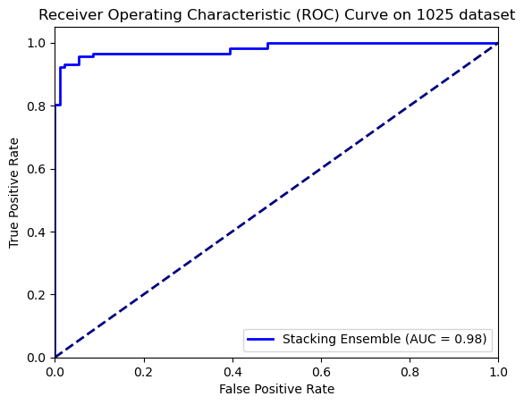

```python
# STACKING MODELS RF + xGBM + SVM + CNN

# Import necessary libraries
import numpy as np
from sklearn.ensemble import RandomForestClassifier
from xgboost import XGBClassifier
from sklearn.svm import SVC
from sklearn.linear_model import LogisticRegression
from tensorflow.keras.models import Sequential
from tensorflow.keras.layers import Conv1D, MaxPooling1D, Flatten, Dense, GRU, Input
from tensorflow.keras.models import Model
from tensorflow.keras.optimizers import Adam
from sklearn.metrics import classification_report, roc_auc_score, roc_curve
import matplotlib.pyplot as plt

# Check if X_train and X_test are already NumPy arrays
if not isinstance(X_train, np.ndarray):
    X_train_np = X_train.to_numpy()
else:
    X_train_np = X_train

if not isinstance(X_test, np.ndarray):
    X_test_np = X_test.to_numpy()
else:
    X_test_np = X_test

# Define and train traditional machine learning models
rf = RandomForestClassifier(max_depth=3, n_estimators=30, min_samples_leaf=5, random_state=42)
xgbm = XGBClassifier(max_depth=3, min_child_weight=10, subsample=0.7, colsample_bytree=0.7, random_state=42)
svm = SVC(C=1.0, kernel='linear', probability=True, random_state=42)

rf.fit(X_train_np, y_train)
xgbm.fit(X_train_np, y_train)
svm.fit(X_train_np, y_train)

# Define and train a CNN model
def create_cnn_model(input_shape):
    model = Sequential([
        Conv1D(32, kernel_size=2, activation='relu', input_shape=input_shape),
        MaxPooling1D(pool_size=2),
        Flatten(),
        Dense(64, activation='relu'),
        Dense(1, activation='sigmoid')
    ])
    model.compile(optimizer='adam', loss='binary_crossentropy', metrics=['accuracy'])
    return model

X_train_cnn = X_train_np.reshape(X_train_np.shape[0], X_train_np.shape[1], 1)
X_test_cnn = X_test_np.reshape(X_test_np.shape[0], X_test_np.shape[1], 1)

cnn_model = create_cnn_model((X_train_np.shape[1], 1))
cnn_model.fit(X_train_cnn, y_train, epochs=50, batch_size=32, validation_split=0.2)

# Generate predictions for training data
rf_train_pred = rf.predict_proba(X_train_np)[:, 1]
xgbm_train_pred = xgbm.predict_proba(X_train_np)[:, 1]
svm_train_pred = svm.predict_proba(X_train_np)[:, 1]

cnn_train_pred = cnn_model.predict(X_train_cnn).ravel()

# Combine predictions into a single training set for the meta-learner
stacked_train_pred = np.column_stack((rf_train_pred, xgbm_train_pred, svm_train_pred, cnn_train_pred))

# Generate predictions for test data
rf_test_pred = rf.predict_proba(X_test_np)[:, 1]
xgbm_test_pred = xgbm.predict_proba(X_test_np)[:, 1]
svm_test_pred = svm.predict_proba(X_test_np)[:, 1]

cnn_test_pred = cnn_model.predict(X_test_cnn).ravel()

# Combine predictions into a single test set for the meta-learner
stacked_test_pred = np.column_stack((rf_test_pred, xgbm_test_pred, svm_test_pred, cnn_test_pred))

# Train the meta-learner on the stacked predictions
meta_model = LogisticRegression()
meta_model.fit(stacked_train_pred, y_train)

# Evaluate the stacking ensemble
y_pred_stack = meta_model.predict(stacked_test_pred)
y_proba_stack = meta_model.predict_proba(stacked_test_pred)[:, 1]

# Print evaluation metrics
print("Stacking Ensemble with RF + xGBM + SVM. + CNN on 1025 dataset")
print(classification_report(y_test, y_pred_stack))
roc_auc_stack = roc_auc_score(y_test, y_proba_stack)
print(f'ROC AUC with RF + xGBM + SVM. + CNN on 1025 dataset: {roc_auc_stack:.2f}')

# Plot the ROC curve
fpr, tpr, _ = roc_curve(y_test, y_proba_stack)
plt.figure()
plt.plot(fpr, tpr, color='blue', lw=2, label=f'Stacking Ensemble (AUC = {roc_auc_stack:.2f})')
plt.plot([0, 1], [0, 1], color='navy', lw=2, linestyle='--')
plt.xlim([0.0, 1.0])
plt.ylim([0.0, 1.05])
plt.xlabel('False Positive Rate')
plt.ylabel('True Positive Rate')
plt.title('Receiver Operating Characteristic (ROC) Curve on 1025 dataset')
plt.legend(loc="lower right")
plt.show()
```

```
21/21 ━━━━━━━━━━━━━━━━━━━━ 1s 8ms/step - accuracy: 0.5293 - loss: 0.6849 - val_accuracy: 0.7456 - val_loss: 0.6167
21/21 ━━━━━━━━━━━━━━━━━━━━ 0s 3ms/step - accuracy: 0.7795 - loss: 0.5723 - val_accuracy: 0.7692 - val_loss: 0.5364
21/21 ━━━━━━━━━━━━━━━━━━━━ 0s 3ms/step - accuracy: 0.7986 - loss: 0.4810 - val_accuracy: 0.7988 - val_loss: 0.4743
21/21 ━━━━━━━━━━━━━━━━━━━━ 0s 3ms/step - accuracy: 0.8529 - loss: 0.3907 - val_accuracy: 0.7988 - val_loss: 0.4336
21/21 ━━━━━━━━━━━━━━━━━━━━ 0s 3ms/step - accuracy: 0.8634 - loss: 0.3564 - val_accuracy: 0.8107 - val_loss: 0.4160
21/21 ━━━━━━━━━━━━━━━━━━━━ 0s 3ms/step - accuracy: 0.8677 - loss: 0.3433 - val_accuracy: 0.8225 - val_loss: 0.4033
21/21 ━━━━━━━━━━━━━━━━━━━━ 0s 3ms/step - accuracy: 0.8664 - loss: 0.3300 - val_accuracy: 0.8047 - val_loss: 0.3961
21/21 ━━━━━━━━━━━━━━━━━━━━ 0s 3ms/step - accuracy: 0.8536 - loss: 0.3353 - val_accuracy: 0.8225 - val_loss: 0.3929
21/21 ━━━━━━━━━━━━━━━━━━━━ 0s 3ms/step - accuracy: 0.8484 - loss: 0.3509 - val_accuracy: 0.8225 - val_loss: 0.3924
21/21 ━━━━━━━━━━━━━━━━━━━━ 0s 3ms/step - accuracy: 0.8741 - loss: 0.3284 - val_accuracy: 0.8284 - val_loss: 0.3869
21/21 ━━━━━━━━━━━━━━━━━━━━ 0s 3ms/step - accuracy: 0.8843 - loss: 0.2980 - val_accuracy: 0.8402 - val_loss: 0.3913
21/21 ━━━━━━━━━━━━━━━━━━━━ 0s 3ms/step - accuracy: 0.9007 - loss: 0.2648 - val_accuracy: 0.8402 - val_loss: 0.3905
21/21 ━━━━━━━━━━━━━━━━━━━━ 0s 3ms/step - accuracy: 0.8701 - loss: 0.3075 - val_accuracy: 0.8462 - val_loss: 0.3888
21/21 ━━━━━━━━━━━━━━━━━━━━ 0s 3ms/step - accuracy: 0.8906 - loss: 0.2712 - val_accuracy: 0.8521 - val_loss: 0.3815
21/21 ━━━━━━━━━━━━━━━━━━━━ 0s 3ms/step - accuracy: 0.8906 - loss: 0.2680 - val_accuracy: 0.8521 - val_loss: 0.3740
21/21 ━━━━━━━━━━━━━━━━━━━━ 0s 3ms/step - accuracy: 0.9245 - loss: 0.2411 - val_accuracy: 0.8343 - val_loss: 0.3760
21/21 ━━━━━━━━━━━━━━━━━━━━ 0s 3ms/step - accuracy: 0.8882 - loss: 0.2727 - val_accuracy: 0.8639 - val_loss: 0.3772
21/21 ━━━━━━━━━━━━━━━━━━━━ 0s 3ms/step - accuracy: 0.9062 - loss: 0.2597 - val_accuracy: 0.8462 - val_loss: 0.3654
21/21 ━━━━━━━━━━━━━━━━━━━━ 0s 3ms/step - accuracy: 0.9219 - loss: 0.2294 - val_accuracy: 0.8402 - val_loss: 0.3558
21/21 ━━━━━━━━━━━━━━━━━━━━ 0s 3ms/step - accuracy: 0.9351 - loss: 0.1929 - val_accuracy: 0.8639 - val_loss: 0.3486
21/21 ━━━━━━━━━━━━━━━━━━━━ 0s 3ms/step - accuracy: 0.9237 - loss: 0.2012 - val_accuracy: 0.8462 - val_loss: 0.3407
21/21 ━━━━━━━━━━━━━━━━━━━━ 0s 3ms/step - accuracy: 0.9323 - loss: 0.1806 - val_accuracy: 0.8639 - val_loss: 0.3347
21/21 ━━━━━━━━━━━━━━━━━━━━ 0s 3ms/step - accuracy: 0.9404 - loss: 0.1584 - val_accuracy: 0.8757 - val_loss: 0.3316
21/21 ━━━━━━━━━━━━━━━━━━━━ 0s 3ms/step - accuracy: 0.9347 - loss: 0.1410 - val_accuracy: 0.8580 - val_loss: 0.3192
21/21 ━━━━━━━━━━━━━━━━━━━━ 0s 3ms/step - accuracy: 0.9560 - loss: 0.1355 - val_accuracy: 0.8698 - val_loss: 0.2996
21/21 ━━━━━━━━━━━━━━━━━━━━ 0s 3ms/step - accuracy: 0.9559 - loss: 0.1426 - val_accuracy: 0.8935 - val_loss: 0.2863
21/21 ━━━━━━━━━━━━━━━━━━━━ 0s 3ms/step - accuracy: 0.9550 - loss: 0.1122 - val_accuracy: 0.9112 - val_loss: 0.2812
21/21 ━━━━━━━━━━━━━━━━━━━━ 0s 3ms/step - accuracy: 0.9555 - loss: 0.1442 - val_accuracy: 0.9112 - val_loss: 0.2590
21/21 ━━━━━━━━━━━━━━━━━━━━ 0s 3ms/step - accuracy: 0.9700 - loss: 0.1017 - val_accuracy: 0.9172 - val_loss: 0.2596
21/21 ━━━━━━━━━━━━━━━━━━━━ 0s 3ms/step - accuracy: 0.9714 - loss: 0.1031 - val_accuracy: 0.9112 - val_loss: 0.2537
21/21 ━━━━━━━━━━━━━━━━━━━━ 0s 3ms/step - accuracy: 0.9757 - loss: 0.0989 - val_accuracy: 0.9349 - val_loss: 0.2411
21/21 ━━━━━━━━━━━━━━━━━━━━ 0s 3ms/step - accuracy: 0.9810 - loss: 0.0859 - val_accuracy: 0.9290 - val_loss: 0.2388
21/21 ━━━━━━━━━━━━━━━━━━━━ 0s 3ms/step - accuracy: 0.9839 - loss: 0.0768 - val_accuracy: 0.9290 - val_loss: 0.2248
21/21 ━━━━━━━━━━━━━━━━━━━━ 0s 3ms/step - accuracy: 0.9918 - loss: 0.0636 - val_accuracy: 0.9290 - val_loss: 0.2083
21/21 ━━━━━━━━━━━━━━━━━━━━ 0s 3ms/step - accuracy: 0.9865 - loss: 0.0620 - val_accuracy: 0.9349 - val_loss: 0.2139
21/21 ━━━━━━━━━━━━━━━━━━━━ 0s 3ms/step - accuracy: 0.9914 - loss: 0.0472 - val_accuracy: 0.9349 - val_loss: 0.2110
21/21 ━━━━━━━━━━━━━━━━━━━━ 0s 3ms/step - accuracy: 0.9880 - loss: 0.0596 - val_accuracy: 0.9467 - val_loss: 0.1792
21/21 ━━━━━━━━━━━━━━━━━━━━ 0s 3ms/step - accuracy: 0.9853 - loss: 0.0518 - val_accuracy: 0.9467 - val_loss: 0.1793
21/21 ━━━━━━━━━━━━━━━━━━━━ 0s 3ms/step - accuracy: 0.9924 - loss: 0.0394 - val_accuracy: 0.9467 - val_loss: 0.1695
21/21 ━━━━━━━━━━━━━━━━━━━━ 0s 3ms/step - accuracy: 0.9881 - loss: 0.0479 - val_accuracy: 0.9704 - val_loss: 0.1564
```

[output cut: 8 more lines]

```
21/21 ━━━━━━━━━━━━━━━━━━━━ 0s 3ms/step - accuracy: 1.0000 - loss: 0.0101 - val_accuracy: 0.9763 - val_loss: 0.1518
21/21 ━━━━━━━━━━━━━━━━━━━━ 0s 3ms/step - accuracy: 1.0000 - loss: 0.0110 - val_accuracy: 0.9763 - val_loss: 0.1488
27/27 ━━━━━━━━━━━━━━━━━━━━ 0s 3ms/step
7/7 ━━━━━━━━━━━━━━━━━━━━ 0s 1ms/step
Stacking Ensemble with RF + xGBM + GBM + RNN on 1025 dataset
              precision    recall  f1-score   support

           0       0.98      0.96      0.97        94
           1       0.97      0.98      0.97       117

    accuracy                           0.97       211
   macro avg       0.97      0.97      0.97       211
weighted avg       0.97      0.97      0.97       211

ROC AUC with RF + xGBM + GBM + RNN on 1025 dataset: 0.99
```

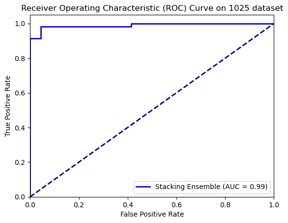

```python
# STACKING MODELS RF + xGBM + GBM + RNN

# Import necessary libraries
import numpy as np
from sklearn.ensemble import RandomForestClassifier
from sklearn.ensemble import GradientBoostingClassifier
from xgboost import XGBClassifier
from sklearn.svm import SVC
from sklearn.linear_model import LogisticRegression
from tensorflow.keras.models import Sequential
from tensorflow.keras.layers import Conv1D, MaxPooling1D, Flatten, Dense, GRU, Input
from tensorflow.keras.models import Model
from tensorflow.keras.optimizers import Adam
from sklearn.metrics import classification_report, roc_auc_score, roc_curve
import matplotlib.pyplot as plt

# Define and train traditional machine learning models

rf = RandomForestClassifier(max_depth=3, n_estimators=30, min_samples_leaf=5, random_state=42)
xgbm = XGBClassifier(max_depth=3, min_child_weight=10, subsample=0.7, colsample_bytree=0.7, random_state=42)
gbm = GradientBoostingClassifier(max_depth=3, n_estimators=30, min_samples_leaf=5, random_state=42)

rf.fit(X_train, y_train)
xgbm.fit(X_train, y_train)
gbm.fit(X_train, y_train)

# Define and train an RNN model (GRU)
def create_gru_model(input_shape):
    inputs = Input(shape=input_shape)
    gru_layer = GRU(64, return_sequences=True)(inputs)
    flatten_layer = Flatten()(gru_layer)
    output_layer = Dense(1, activation='sigmoid')(flatten_layer)
    model = Model(inputs=inputs, outputs=output_layer)
    model.compile(optimizer='adam', loss='binary_crossentropy', metrics=['accuracy'])
    return model

gru_model = create_gru_model((X_train.shape[1], 1))
gru_model.fit(X_train_cnn, y_train, epochs=50, batch_size=32, validation_split=0.2)

# Generate predictions for training data
rf_train_pred = rf.predict_proba(X_train)[:, 1]
xgbm_train_pred = xgbm.predict_proba(X_train)[:, 1]
gbm_train_pred = gbm.predict_proba(X_train)[:, 1]

gru_train_pred = gru_model.predict(X_train_cnn).ravel()

# Combine predictions into a single training set for the meta-learner
stacked_train_pred = np.column_stack((rf_train_pred, xgbm_train_pred, gbm_train_pred, gru_train_pred))

# Generate predictions for test data
rf_test_pred = rf.predict_proba(X_test)[:, 1]
xgbm_test_pred = xgbm.predict_proba(X_test)[:, 1]
gbm_test_pred = gbm.predict_proba(X_test)[:, 1]

gru_test_pred = gru_model.predict(X_test_cnn).ravel()

# Combine predictions into a single test set for the meta-learner
stacked_test_pred = np.column_stack((rf_test_pred, xgbm_test_pred, gbm_test_pred, gru_test_pred))

# Train the meta-learner on the stacked predictions
meta_model = LogisticRegression()
meta_model.fit(stacked_train_pred, y_train)

# Evaluate the stacking ensemble
y_pred_stack = meta_model.predict(stacked_test_pred)
y_proba_stack = meta_model.predict_proba(stacked_test_pred)[:, 1]

# Print evaluation metrics
print("Stacking Ensemble with RF + xGBM + GBM + RNN on 1025 dataset")
print(classification_report(y_test, y_pred_stack))
roc_auc_stack = roc_auc_score(y_test, y_proba_stack)
print(f'ROC AUC with RF + xGBM + GBM + RNN on 1025 dataset: {roc_auc_stack:.2f}')

# Plot the ROC curve
fpr, tpr, _ = roc_curve(y_test, y_proba_stack)
plt.figure()
plt.plot(fpr, tpr, color='blue', lw=2, label=f'Stacking Ensemble (AUC = {roc_auc_stack:.2f})')
plt.plot([0, 1], [0, 1], color='navy', lw=2, linestyle='--')
plt.xlim([0.0, 1.0])
plt.ylim([0.0, 1.05])
plt.xlabel('False Positive Rate')
plt.ylabel('True Positive Rate')
plt.title('Receiver Operating Characteristic (ROC) Curve on 1025 dataset')
plt.legend(loc="lower right")
plt.show()
```

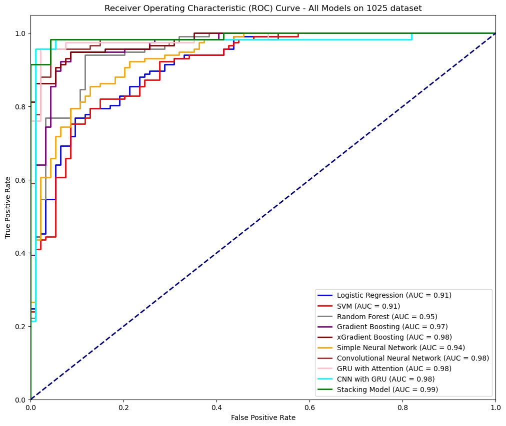

```python
# ALL ROC Curve in one place

import matplotlib.pyplot as plt
from sklearn.metrics import roc_curve, roc_auc_score

# Calculate ROC curve and AUC for each updated model
fpr_lr, tpr_lr, _ = roc_curve(y_test, y_proba_lr)
roc_auc_lr = roc_auc_score(y_test, y_proba_lr)

fpr_svm, tpr_svm, _ = roc_curve(y_test, y_proba_svm)
roc_auc_svm = roc_auc_score(y_test, y_proba_svm)

fpr_rf, tpr_rf, _ = roc_curve(y_test, y_proba_rf)
roc_auc_rf = roc_auc_score(y_test, y_proba_rf)

fpr_gbm, tpr_gbm, _ = roc_curve(y_test, y_proba_gbm)
roc_auc_gbm = roc_auc_score(y_test, y_proba_gbm)

fpr_xgbm, tpr_xgbm, _ = roc_curve(y_test, y_proba_xgbm)
roc_auc_xgbm = roc_auc_score(y_test, y_proba_xgbm)

fpr_nn, tpr_nn, _ = roc_curve(y_test, y_proba_nn)
roc_auc_nn = roc_auc_score(y_test, y_proba_nn)

fpr_cnn, tpr_cnn, _ = roc_curve(y_test, y_proba_cnn)
roc_auc_cnn = roc_auc_score(y_test, y_proba_cnn)

fpr_gru_attention, tpr_gru_attention, _ = roc_curve(y_test, y_proba_gru_attention)
roc_auc_gru_attention = roc_auc_score(y_test, y_proba_gru_attention)

fpr_cnn_gru, tpr_cnn_gru, _ = roc_curve(y_test, y_proba_cnn_gru)
roc_auc_cnn_gru = roc_auc_score(y_test, y_proba_cnn_gru)

fpr, tpr, _ = roc_curve(y_test, y_proba_stack)
roc_auc_stack = roc_auc_score(y_test, y_proba_stack)

# Plot all ROC curves on the same plot
#plt.figure()
fig, ax = plt.subplots(figsize=(12, 10))

plt.plot(fpr_lr, tpr_lr, color='blue', lw=2, label=f'Logistic Regression (AUC = {roc_auc_lr:.2f})')
plt.plot(fpr_svm, tpr_svm, color='red', lw=2, label=f'SVM (AUC = {roc_auc_svm:.2f})')
plt.plot(fpr_rf, tpr_rf, color='gray', lw=2, label=f'Random Forest (AUC = {roc_auc_rf:.2f})')
plt.plot(fpr_gbm, tpr_gbm, color='purple', lw=2, label=f'Gradient Boosting (AUC = {roc_auc_gbm:.2f})')
plt.plot(fpr_xgbm, tpr_xgbm, color='darkred', lw=2, label=f'xGradient Boosting (AUC = {roc_auc_xgbm:.2f})')
plt.plot(fpr_nn, tpr_nn, color='orange', lw=2, label=f'Simple Neural Network (AUC = {roc_auc_nn:.2f})')
plt.plot(fpr_cnn, tpr_cnn, color='brown', lw=2, label=f'Convolutional Neural Network (AUC = {roc_auc_cnn:.2f})')
plt.plot(fpr_gru_attention, tpr_gru_attention, color='pink', lw=2, label=f'GRU with Attention (AUC = {roc_auc_gru_attention:.2f})')
plt.plot(fpr_cnn_gru, tpr_cnn_gru, color='cyan', lw=2, label=f'CNN with GRU (AUC = {roc_auc_cnn_gru:.2f})')
plt.plot(fpr, tpr, color='green', lw=2, label=f'Stacking Model (AUC = {roc_auc_stack:.2f})')

plt.plot([0, 1], [0, 1], color='navy', lw=2, linestyle='--')
plt.xlim([0.0, 1.0])
plt.ylim([0.0, 1.05])
plt.xlabel('False Positive Rate')
plt.ylabel('True Positive Rate')
plt.title('Receiver Operating Characteristic (ROC) Curve - All Models on 1025 dataset')
plt.legend(loc="lower right")
plt.show()
```